# PROJECT 5 Credit Card Users Churn Prediction

##### Libraries

```python
pip install xgboost
```

```python
pip install xlrd
```

```python
#To install xgboost library use -
!pip install xgboost
### IMPORT: ------------------------------------
import scipy.stats as stats
import pandas as pd
import numpy as np

import matplotlib.pyplot as plt
%matplotlib inline
import seaborn as sns
import warnings

import statsmodels.api as sm
#--Sklearn library--
from sklearn.model_selection import train_test_split # Sklearn package's randomized data splitting function

from sklearn import metrics

from sklearn.ensemble import BaggingClassifier,RandomForestClassifier,StackingClassifier
from sklearn.tree import DecisionTreeClassifier
from sklearn.ensemble import AdaBoostClassifier, GradientBoostingClassifier

from xgboost import XGBClassifier
from sklearn import tree
from sklearn.linear_model import LogisticRegression

# Libtune to tune model, get different metric scores

from sklearn.metrics import  classification_report, accuracy_score, precision_score, recall_score,f1_score
from sklearn.model_selection import GridSearchCV
from sklearn.metrics import confusion_matrix,ConfusionMatrixDisplay,plot_confusion_matrix #to plot confusion matric

pd.set_option('display.float_format', lambda x: '%.3f' % x)
pd.set_option('display.max_rows', 300)
pd.set_option('display.max_colwidth',400)
# To supress numerical display in scientific notations
pd.set_option('display.float_format', lambda x: '%.5f' % x)
warnings.filterwarnings('ignore') # To supress warnings
 # set the background for the graphs
plt.style.use('ggplot')
```

```python
import time
start_time = time.time()
```

### Stage 1 - Understanding the Data

##### 1.1. Import Dataset

```python
df = pd.read_csv('C:/Users/srikant/Downloads/BankChurners.csv')
```

```python
# slice the DataFrame, excluding 2 last columns, and reassign to 'df'
df = df.iloc[:,:-2]
```

##### 1.2. Preview Dataset

```python
# set option to show all columns without truncation
pd.set_option('max_columns', None)

# Preview the top 10 rows
df.head(10)
```

|  | CLIENTNUM | Attrition_Flag | Customer_Age | Gender | Dependent_count | Education_Level | Marital_Status | Income_Category | Card_Category | Months_on_book | Total_Relationship_Count | Months_Inactive_12_mon | Contacts_Count_12_mon | Credit_Limit | Total_Revolving_Bal | Avg_Open_To_Buy | Total_Amt_Chng_Q4_Q1 | Total_Trans_Amt | Total_Trans_Ct | Total_Ct_Chng_Q4_Q1 | Avg_Utilization_Ratio |
| --- | --- | --- | --- | --- | --- | --- | --- | --- | --- | --- | --- | --- | --- | --- | --- | --- | --- | --- | --- | --- | --- |
| 0 | 768805383 | Existing Customer | 45 | M | 3 | High School | Married | $60K - $80K | Blue | 39 | 5 | 1 | 3 | 12691.00000 | 777 | 11914.00000 | 1.33500 | 1144 | 42 | 1.62500 | 0.06100 |
| 1 | 818770008 | Existing Customer | 49 | F | 5 | Graduate | Single | Less than $40K | Blue | 44 | 6 | 1 | 2 | 8256.00000 | 864 | 7392.00000 | 1.54100 | 1291 | 33 | 3.71400 | 0.10500 |
| 2 | 713982108 | Existing Customer | 51 | M | 3 | Graduate | Married | $80K - $120K | Blue | 36 | 4 | 1 | 0 | 3418.00000 | 0 | 3418.00000 | 2.59400 | 1887 | 20 | 2.33300 | 0.00000 |
| 3 | 769911858 | Existing Customer | 40 | F | 4 | High School | Unknown | Less than $40K | Blue | 34 | 3 | 4 | 1 | 3313.00000 | 2517 | 796.00000 | 1.40500 | 1171 | 20 | 2.33300 | 0.76000 |
| 4 | 709106358 | Existing Customer | 40 | M | 3 | Uneducated | Married | $60K - $80K | Blue | 21 | 5 | 1 | 0 | 4716.00000 | 0 | 4716.00000 | 2.17500 | 816 | 28 | 2.50000 | 0.00000 |
| 5 | 713061558 | Existing Customer | 44 | M | 2 | Graduate | Married | $40K - $60K | Blue | 36 | 3 | 1 | 2 | 4010.00000 | 1247 | 2763.00000 | 1.37600 | 1088 | 24 | 0.84600 | 0.31100 |
| 6 | 810347208 | Existing Customer | 51 | M | 4 | Unknown | Married | $120K + | Gold | 46 | 6 | 1 | 3 | 34516.00000 | 2264 | 32252.00000 | 1.97500 | 1330 | 31 | 0.72200 | 0.06600 |
| 7 | 818906208 | Existing Customer | 32 | M | 0 | High School | Unknown | $60K - $80K | Silver | 27 | 2 | 2 | 2 | 29081.00000 | 1396 | 27685.00000 | 2.20400 | 1538 | 36 | 0.71400 | 0.04800 |
| 8 | 710930508 | Existing Customer | 37 | M | 3 | Uneducated | Single | $60K - $80K | Blue | 36 | 5 | 2 | 0 | 22352.00000 | 2517 | 19835.00000 | 3.35500 | 1350 | 24 | 1.18200 | 0.11300 |
| 9 | 719661558 | Existing Customer | 48 | M | 2 | Graduate | Single | $80K - $120K | Blue | 36 | 6 | 3 | 3 | 11656.00000 | 1677 | 9979.00000 | 1.52400 | 1441 | 32 | 0.88200 | 0.14400 |

```python
# find rows and columns count
df.shape
```

```
(10127, 21)
```

```python
# see dataset info
df.info()
```

```
<class 'pandas.core.frame.DataFrame'>
RangeIndex: 10127 entries, 0 to 10126
Data columns (total 21 columns):
 #   Column                    Non-Null Count  Dtype
---  ------                    --------------  -----
 0   CLIENTNUM                 10127 non-null  int64
 1   Attrition_Flag            10127 non-null  object
 2   Customer_Age              10127 non-null  int64
 3   Gender                    10127 non-null  object
 4   Dependent_count           10127 non-null  int64
 5   Education_Level           10127 non-null  object
 6   Marital_Status            10127 non-null  object
 7   Income_Category           10127 non-null  object
 8   Card_Category             10127 non-null  object
 9   Months_on_book            10127 non-null  int64
 10  Total_Relationship_Count  10127 non-null  int64
 11  Months_Inactive_12_mon    10127 non-null  int64
 12  Contacts_Count_12_mon     10127 non-null  int64
 13  Credit_Limit              10127 non-null  float64
 14  Total_Revolving_Bal       10127 non-null  int64
 15  Avg_Open_To_Buy           10127 non-null  float64
 16  Total_Amt_Chng_Q4_Q1      10127 non-null  float64
 17  Total_Trans_Amt           10127 non-null  int64
 18  Total_Trans_Ct            10127 non-null  int64
 19  Total_Ct_Chng_Q4_Q1       10127 non-null  float64
 20  Avg_Utilization_Ratio     10127 non-null  float64
dtypes: float64(5), int64(10), object(6)
memory usage: 1.6+ MB
```

```python
#find unique values for each columns
for col in df:
    uniq = df[col].value_counts()
    print(uniq, '\n==============\n')
```

```
768805383    1
711784908    1
720133908    1
803197833    1
812222208    1
            ..
796903083    1
716014983    1
712521783    1
780045708    1
714337233    1
Name: CLIENTNUM, Length: 10127, dtype: int64
==============

Existing Customer    8500
Attrited Customer    1627
Name: Attrition_Flag, dtype: int64
==============

44    500
49    495
46    490
45    486
47    479
43    473
48    472
50    452
42    426
51    398
53    387
41    379
52    376
40    361
39    333
54    307
38    303
55    279
56    262
37    260
57    223
```

[output cut: 361 more lines]

```
==============

0.00000    2470
0.07300      44
0.05700      33
0.04800      32
0.06000      30
           ...
0.92700       1
0.93500       1
0.95400       1
0.38500       1
0.00900       1
Name: Avg_Utilization_Ratio, Length: 964, dtype: int64
==============
```

### Stage 2 - Identifying Activities

Based on our initial Data Understanding stage, we can identify some activities that needs to be done on the dataset:

1. Remove Unnecessary Features: the dataset might have some features that are unnecessary for our modelling, that is features that cannot be used as predictor. Remove them before doing EDA
2. Handle Missing Value: make sure that the dataset doesn't have any missing value
3. Exploratory Data Analysis: explore the features statistically, and use visualization to get a better view of the data
4. Handle Categorical Data: categorical data needs to be encoded before modelling
5. Handle Numerical Data: scale the numerical data with Standardization or Normalization

### Stage 3 - EDA & Visualization

##### 3.1. Unnecessary Feature Removal

Before processing further, we need to remove features that cannot be used on modelling. The CLIENTNUM feature contains unique ID for every customer so it can not be used as Predictor (input) for the Target (output), and should be dropped

```python
# slice the DataFrame, excluding CLIENTNUM column at index 0, and reassign to 'df'
df = df.iloc[:,1:]

# see the updated df information
df.info()
```

```
<class 'pandas.core.frame.DataFrame'>
RangeIndex: 10127 entries, 0 to 10126
Data columns (total 20 columns):
 #   Column                    Non-Null Count  Dtype
---  ------                    --------------  -----
 0   Attrition_Flag            10127 non-null  object
 1   Customer_Age              10127 non-null  int64
 2   Gender                    10127 non-null  object
 3   Dependent_count           10127 non-null  int64
 4   Education_Level           10127 non-null  object
 5   Marital_Status            10127 non-null  object
 6   Income_Category           10127 non-null  object
 7   Card_Category             10127 non-null  object
 8   Months_on_book            10127 non-null  int64
 9   Total_Relationship_Count  10127 non-null  int64
 10  Months_Inactive_12_mon    10127 non-null  int64
 11  Contacts_Count_12_mon     10127 non-null  int64
 12  Credit_Limit              10127 non-null  float64
 13  Total_Revolving_Bal       10127 non-null  int64
 14  Avg_Open_To_Buy           10127 non-null  float64
 15  Total_Amt_Chng_Q4_Q1      10127 non-null  float64
 16  Total_Trans_Amt           10127 non-null  int64
 17  Total_Trans_Ct            10127 non-null  int64
 18  Total_Ct_Chng_Q4_Q1       10127 non-null  float64
 19  Avg_Utilization_Ratio     10127 non-null  float64
dtypes: float64(5), int64(9), object(6)
memory usage: 1.5+ MB
```

Now that we have all relevant features, each with their correct data type, let's define which features are numerical and categorical and assign each to a variable.

```python
#define categorical columns
cat_cols = list(df.select_dtypes('object'))
cat_cols
```

```
['Attrition_Flag',
 'Gender',
 'Education_Level',
 'Marital_Status',
 'Income_Category',
 'Card_Category']
```

```python
#define numerical columns
num_cols = list(df.select_dtypes(['int64','float64']))
num_cols
```

```
['Customer_Age',
 'Dependent_count',
 'Months_on_book',
 'Total_Relationship_Count',
 'Months_Inactive_12_mon',
 'Contacts_Count_12_mon',
 'Credit_Limit',
 'Total_Revolving_Bal',
 'Avg_Open_To_Buy',
 'Total_Amt_Chng_Q4_Q1',
 'Total_Trans_Amt',
 'Total_Trans_Ct',
 'Total_Ct_Chng_Q4_Q1',
 'Avg_Utilization_Ratio']
```

##### 3.2. Missing Value Check

Make Sure that the data has no missing value

```python
df.isnull().sum()
```

```
Attrition_Flag              0
Customer_Age                0
Gender                      0
Dependent_count             0
Education_Level             0
Marital_Status              0
Income_Category             0
Card_Category               0
Months_on_book              0
Total_Relationship_Count    0
Months_Inactive_12_mon      0
Contacts_Count_12_mon       0
Credit_Limit                0
Total_Revolving_Bal         0
Avg_Open_To_Buy             0
Total_Amt_Chng_Q4_Q1        0
Total_Trans_Amt             0
Total_Trans_Ct              0
Total_Ct_Chng_Q4_Q1         0
Avg_Utilization_Ratio       0
dtype: int64
```

Treating Null values for Education Level

```python
df['Education_Level'].value_counts()
```

```
Graduate         3128
High School      2013
Unknown          1519
Uneducated       1487
College          1013
Post-Graduate     516
Doctorate         451
Name: Education_Level, dtype: int64
```

```python
df['Education_Level'].mode()

df['Education_Level']=df['Education_Level'].fillna('Graduate')
```

```python
#Verify if there are null values
df["Education_Level"].isnull().sum()
```

```
0
```

Treating Null values for Marital status

```python
df['Marital_Status'].value_counts()
```

```
Married     4687
Single      3943
Unknown      749
Divorced     748
Name: Marital_Status, dtype: int64
```

```python
df['Marital_Status'].mode()

df['Marital_Status']=df['Marital_Status'].fillna('Married')
```

```python
#Verify if there are null values
df["Education_Level"].isnull().sum()
```

```
0
```

```python
df.isnull().sum()
```

```
Attrition_Flag              0
Customer_Age                0
Gender                      0
Dependent_count             0
Education_Level             0
Marital_Status              0
Income_Category             0
Card_Category               0
Months_on_book              0
Total_Relationship_Count    0
Months_Inactive_12_mon      0
Contacts_Count_12_mon       0
Credit_Limit                0
Total_Revolving_Bal         0
Avg_Open_To_Buy             0
Total_Amt_Chng_Q4_Q1        0
Total_Trans_Amt             0
Total_Trans_Ct              0
Total_Ct_Chng_Q4_Q1         0
Avg_Utilization_Ratio       0
dtype: int64
```

Conclusion: there is no missing value found on the dataset

##### 3.3. Target Feature Exploration

The Target Feature (output) that we want to predict is Attrition_Flag, which has two unique values, that is 'Existing Customer' and 'Attrited Customer'. Before doing the exploration, encode those values into 0 and 1.

```python
# Encode Attrition_Flag
df['Attrition_Flag'] = df['Attrition_Flag'].map({'Existing Customer': 0,
                                                 'Attrited Customer':1})
```

We will use visualization in exploring the features of the dataset, so we need to import the required libraries

```python
# import visualization libraries
import matplotlib.pyplot as plt
%matplotlib inline

import seaborn as sns
sns.set_palette('pastel')
```

###### 3.3.1. Target Feature Distribution

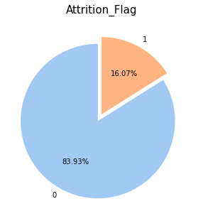

```python
# Prepare the data
attr_count = df['Attrition_Flag'].value_counts()
attr_label = df['Attrition_Flag'].value_counts().index

# Plot
fig,ax = plt.subplots(figsize=(7,5))
# pie plot
ax.pie(attr_count, explode=(0.1,0), labels=attr_label, autopct='%.2f%%', startangle=90)
ax.set_title('Attrition_Flag', fontsize=15)
# show plot
plt.show()
```

Here we can see that we have 16.07% of customers that attrited/churned, or 1627 out of 10127.

##### 3.4. Predictor Features Exploration

Now, let's have a look at the other features, that will be used as predictors for our models.

###### 3.4.1. Numerical Predictor Features

First, define the numerical predictors, which are all the numerical features we defined earlier. Assign it to a variable, as it will be used later for slicing the dataframe.

```python
# define numerical predictors
num_pred = num_cols
num_pred
```

```
['Customer_Age',
 'Dependent_count',
 'Months_on_book',
 'Total_Relationship_Count',
 'Months_Inactive_12_mon',
 'Contacts_Count_12_mon',
 'Credit_Limit',
 'Total_Revolving_Bal',
 'Avg_Open_To_Buy',
 'Total_Amt_Chng_Q4_Q1',
 'Total_Trans_Amt',
 'Total_Trans_Ct',
 'Total_Ct_Chng_Q4_Q1',
 'Avg_Utilization_Ratio']
```

##### 3.4.1.1. Descriptive Statistics¶

```python
# describe the statistics of numerical predictors
num_stat = df[num_pred].describe().transpose().reset_index()
num_stat.rename(columns={'index': 'feature'}, inplace=True)
num_stat
```

|  | feature | count | mean | std | min | 25% | 50% | 75% | max |
| --- | --- | --- | --- | --- | --- | --- | --- | --- | --- |
| 0 | Customer_Age | 10127.00000 | 46.32596 | 8.01681 | 26.00000 | 41.00000 | 46.00000 | 52.00000 | 73.00000 |
| 1 | Dependent_count | 10127.00000 | 2.34620 | 1.29891 | 0.00000 | 1.00000 | 2.00000 | 3.00000 | 5.00000 |
| 2 | Months_on_book | 10127.00000 | 35.92841 | 7.98642 | 13.00000 | 31.00000 | 36.00000 | 40.00000 | 56.00000 |
| 3 | Total_Relationship_Count | 10127.00000 | 3.81258 | 1.55441 | 1.00000 | 3.00000 | 4.00000 | 5.00000 | 6.00000 |
| 4 | Months_Inactive_12_mon | 10127.00000 | 2.34117 | 1.01062 | 0.00000 | 2.00000 | 2.00000 | 3.00000 | 6.00000 |
| 5 | Contacts_Count_12_mon | 10127.00000 | 2.45532 | 1.10623 | 0.00000 | 2.00000 | 2.00000 | 3.00000 | 6.00000 |
| 6 | Credit_Limit | 10127.00000 | 8631.95370 | 9088.77665 | 1438.30000 | 2555.00000 | 4549.00000 | 11067.50000 | 34516.00000 |
| 7 | Total_Revolving_Bal | 10127.00000 | 1162.81406 | 814.98734 | 0.00000 | 359.00000 | 1276.00000 | 1784.00000 | 2517.00000 |
| 8 | Avg_Open_To_Buy | 10127.00000 | 7469.13964 | 9090.68532 | 3.00000 | 1324.50000 | 3474.00000 | 9859.00000 | 34516.00000 |
| 9 | Total_Amt_Chng_Q4_Q1 | 10127.00000 | 0.75994 | 0.21921 | 0.00000 | 0.63100 | 0.73600 | 0.85900 | 3.39700 |
| 10 | Total_Trans_Amt | 10127.00000 | 4404.08630 | 3397.12925 | 510.00000 | 2155.50000 | 3899.00000 | 4741.00000 | 18484.00000 |
| 11 | Total_Trans_Ct | 10127.00000 | 64.85869 | 23.47257 | 10.00000 | 45.00000 | 67.00000 | 81.00000 | 139.00000 |
| 12 | Total_Ct_Chng_Q4_Q1 | 10127.00000 | 0.71222 | 0.23809 | 0.00000 | 0.58200 | 0.70200 | 0.81800 | 3.71400 |
| 13 | Avg_Utilization_Ratio | 10127.00000 | 0.27489 | 0.27569 | 0.00000 | 0.02300 | 0.17600 | 0.50300 | 0.99900 |

###### 3.4.1.2. Distribution

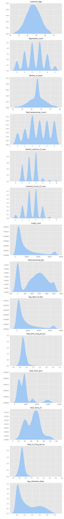

```python
fig, ax = plt.subplots(ncols=1, nrows=14, figsize=(7,70))  #each axes size=7x5

i=0

for col in num_pred:
    sns.kdeplot(x=df[col], fill=True, alpha=1, ax=ax[i])
    ax[i].set_xlabel(' ')
    ax[i].set_ylabel(' ')
    ax[i].set_title(col, fontsize=12)
    i=i+1

plt.show()
```

```python
# check skewness of distribution
skew = []
for col in num_pred:
    skew.append(round(df[col].skew(),3))

num_dist = pd.DataFrame({'feature':num_pred, 'skewness':skew})
num_dist
```

|  | feature | skewness |
| --- | --- | --- |
| 0 | Customer_Age | -0.03400 |
| 1 | Dependent_count | -0.02100 |
| 2 | Months_on_book | -0.10700 |
| 3 | Total_Relationship_Count | -0.16200 |
| 4 | Months_Inactive_12_mon | 0.63300 |
| 5 | Contacts_Count_12_mon | 0.01100 |
| 6 | Credit_Limit | 1.66700 |
| 7 | Total_Revolving_Bal | -0.14900 |
| 8 | Avg_Open_To_Buy | 1.66200 |
| 9 | Total_Amt_Chng_Q4_Q1 | 1.73200 |
| 10 | Total_Trans_Amt | 2.04100 |
| 11 | Total_Trans_Ct | 0.15400 |
| 12 | Total_Ct_Chng_Q4_Q1 | 2.06400 |
| 13 | Avg_Utilization_Ratio | 0.71800 |

Features that have skewness between -0.05 and 0.05 are assumed to have gaussian distribution, which are:

```python
gauss_feat = list(num_dist.query('skewness < 0.05 & skewness > -0.05')['feature'])
gauss_feat
```

```
['Customer_Age', 'Dependent_count', 'Contacts_Count_12_mon']
```

##### 3.4.1.3. Numerical Correlation

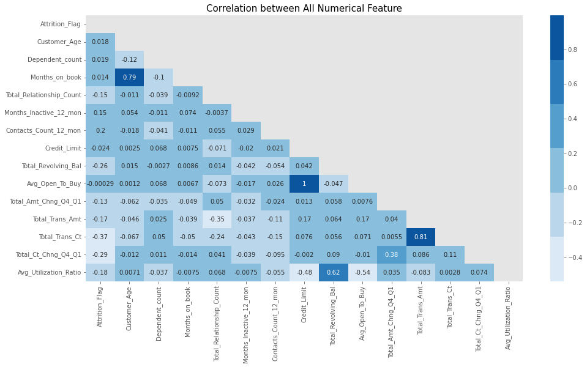

```python
# prepare figure
plt.figure(figsize=(16,8))
plt.title('Correlation between All Numerical Feature', size=15)

# create mask
mask = np.triu(np.ones_like(df.corr()))
# create colormap
colormap = sns.color_palette("Blues")
# plot heatmap
sns.heatmap(df.corr(), annot=True, cmap=colormap, mask=mask)
# sns.heatmap(df.corr(), annot=True, mask=mask)

plt.show()
```

Here we can see that some feature are highly correlated, such as:

1. Avg_Open_To_Buy and Credit_Limit, (1)
2. Total_Trans_Ct and Total_Trans_Amt, (0.81)
3. Months_on_book and Customer_Age, (0.79)

##### 3.4.1.4. Numerical-Target Relationship

```python
# initiate empty list
tg_num_corr = []

# loop to fill tg_num_corr with each columns vs Target correlation coefficient
for col in num_pred:
    tg_num_corr.append(df[col].corr(df['Attrition_Flag']))

# create as DataFrame
tg_num_df = pd.DataFrame({'Numerical_Predictors': num_pred,
                          'Correlation_w_Target': tg_num_corr })

# sort the DataFrame by the absolute value of their correlation coefficient, descending
tg_num_df = tg_num_df.sort_values(by='Correlation_w_Target', key=abs, ascending=False).reset_index(drop=True)

# call the DataFrame
tg_num_df
```

|  | Numerical_Predictors | Correlation_w_Target |
| --- | --- | --- |
| 0 | Total_Trans_Ct | -0.37140 |
| 1 | Total_Ct_Chng_Q4_Q1 | -0.29005 |
| 2 | Total_Revolving_Bal | -0.26305 |
| 3 | Contacts_Count_12_mon | 0.20449 |
| 4 | Avg_Utilization_Ratio | -0.17841 |
| 5 | Total_Trans_Amt | -0.16860 |
| 6 | Months_Inactive_12_mon | 0.15245 |
| 7 | Total_Relationship_Count | -0.15001 |
| 8 | Total_Amt_Chng_Q4_Q1 | -0.13106 |
| 9 | Credit_Limit | -0.02387 |
| 10 | Dependent_count | 0.01899 |
| 11 | Customer_Age | 0.01820 |
| 12 | Months_on_book | 0.01369 |
| 13 | Avg_Open_To_Buy | -0.00029 |

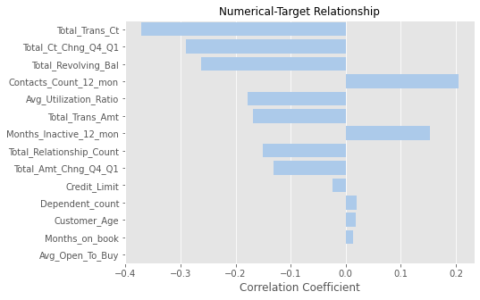

```python
# display as figure
plt.figure(figsize=(7,5))
sns.barplot(x=tg_num_df['Correlation_w_Target'], y=tg_num_df['Numerical_Predictors'], color='#a2c9f4')
plt.ylabel('')
plt.xlabel('Correlation Coefficient')
plt.title('Numerical-Target Relationship', fontsize=12)
plt.show()
```

##### 3.4.1.5. Outlier Detection

#### Box Plot

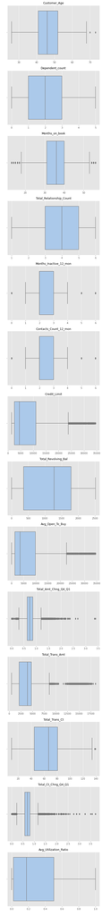

```python
# set the figure
fig, ax = plt.subplots(ncols=1, nrows=14, figsize=(7,70)) #each axes size=7x5
# initiate variable
i=0
# loop
for col in num_pred:
    sns.boxplot(data=df, x=col, ax=ax[i], palette='pastel')
    ax[i].set_xlabel(' ')
    ax[i].set_ylabel(' ')
    ax[i].set_title(col, fontsize=12)
    i=i+1
# show the plot
plt.show()
```

##### Outliers Count

Let's find out the outliers from our dataset. We will use two methods to find the outliers:

1. Inner Fence, and
2. Outer Fence
1. Inner Fence

The lower boundary of this method is defined by Q1 - (1.5 IQR), and the upper boundary is defined by Q3 + (1.5 IQR)

```python
# outliers of each feature using Inner Fence

# initiate empty dictionary and list for the loop
outlier_dict_if = {}          #dict feature and all outliers
outlier_dict_unique_if = {}   #dict feature and unique outliers
# loop each features
for col in num_pred:
    # find upper and lower bound of each features using inner fence
    stats = df[col].describe()
    q1, q3 = stats['25%'], stats['75%']
    iqr = q3-q1
    lower_bound_if = q1 - (1.5 * iqr)
    upper_bound_if = q3 + (1.5 * iqr)

    # set a condition: add data that are outside upper-lower boundary to dict
    # initiate empty list
    outlier_list_if = []
    outlier_list_unique_if = []
    for x in df[col]:
        if ((x > upper_bound_if) or (x < lower_bound_if)):
            outlier_list_if.append(x)
            # if the value is not already in list
            if x not in outlier_list_unique_if:
                outlier_list_unique_if.append(x)
        # append the list to dictionaries
        outlier_dict_if['{}'.format(col)] = outlier_list_if
        outlier_dict_unique_if['{}'.format(col)] = outlier_list_unique_if
```

```python
# see outliers from each features
for k,v in outlier_dict_if.items():
    print(k, 'outliers (inner fence):')
    print(v)
    print('count:',len(v))
    print('====\n')
```

```
Customer_Age outliers (inner fence):
[73, 70]
count: 2
====

Dependent_count outliers (inner fence):
[]
count: 0
====

Months_on_book outliers (inner fence):
[54, 56, 56, 56, 54, 56, 56, 56, 54, 55, 56, 56, 54, 54, 56, 56, 56, 56, 13, 13, 56, 56, 13, 56, 56, 56, 15, 56, 17, 13, 54, 54, 13, 56, 54, 13, 54, 55, 54, 17, 17, 56, 13, 17, 16, 15, 16, 56, 56, 13, 56, 56, 56, 17, 14, 13, 13, 56, 54, 54, 15, 56, 16, 56, 17, 17, 14, 17, 55, 55, 14, 13, 14, 54, 54,…
count: 386
====

Total_Relationship_Count outliers (inner fence):
[]
count: 0
====

Months_Inactive_12_mon outliers (inner fence):
[6, 0, 5, 0, 6, 5, 5, 5, 6, 5, 5, 5, 5, 6, 5, 5, 6, 5, 5, 6, 6, 5, 5, 6, 5, 5, 5, 6, 5, 6, 6, 5, 6, 5, 5, 0, 5, 5, 6, 6, 6, 5, 6, 0, 6, 5, 6, 6, 6, 6, 5, 6, 6, 5, 0, 5, 6, 0, 5, 6, 6, 6, 6, 5, 6, 0, 5, 6, 6, 5, 6, 6, 5, 5, 6, 6, 5, 5, 6, 5, 6, 5, 5, 5, 6, 6, 5, 5, 5, 5, 5, 6, 6, 5, 5, 6, 5, 5, 5, 5,…
count: 331
====

Contacts_Count_12_mon outliers (inner fence):
[0, 0, 0, 0, 0, 0, 0, 0, 0, 0, 0, 0, 0, 0, 0, 0, 0, 0, 0, 0, 0, 0, 0, 0, 0, 0, 0, 0, 0, 0, 0, 0, 0, 0, 0, 0, 0, 0, 0, 0, 0, 0, 0, 0, 0, 0, 0, 0, 0, 0, 0, 0, 0, 0, 0, 0, 0, 0, 0, 0, 0, 0, 0, 0, 0, 0, 0, 0, 0, 0, 0, 0, 0, 0, 0, 0, 0, 0, 0, 0, 0, 0, 0, 0, 0, 0, 0, 0, 0, 0, 0, 0, 0, 0, 0, 0, 0, 0, 0, 0,…
count: 629
====

Credit_Limit outliers (inner fence):
[34516.0, 29081.0, 30367.0, 32426.0, 34516.0, 34516.0, 23957.0, 34516.0, 25300.0, 34516.0, 24312.0, 28904.0, 34516.0, 34516.0, 31302.0, 34516.0, 34516.0, 33791.0, 24159.0, 34516.0, 34516.0, 32090.0, 32643.0, 32975.0, 34516.0, 26792.0, 27259.0, 34516.0, 34516.0, 24407.0, 34516.0, 34516.0, 27756.0, 34…
count: 984
====

Total_Revolving_Bal outliers (inner fence):
[]
count: 0
====

```

[output cut: 14 more lines]

```

Total_Trans_Ct outliers (inner fence):
[139, 138]
count: 2
====

Total_Ct_Chng_Q4_Q1 outliers (inner fence):
[1.625, 3.714, 2.333, 2.333, 2.5, 1.182, 1.364, 3.25, 2.0, 1.7, 1.625, 1.571, 1.3, 1.571, 2.571, 1.6, 1.667, 1.176, 1.2, 0.143, 1.2, 1.333, 1.7, 1.923, 1.417, 1.25, 2.4, 2.0, 1.182, 1.875, 1.412, 2.0, 1.8, 1.636, 1.333, 2.182, 1.222, 1.5, 1.625, 3.0, 1.571, 1.533, 1.417, 2.2, 1.545, 1.211, 1.231, 1.…
count: 394
====

Avg_Utilization_Ratio outliers (inner fence):
[]
count: 0
====
```

```python
# see unique outliers from each features
for k,v in outlier_dict_unique_if.items():
    print(k, 'unique outlier (inner fence):')
    print(v)
    print('count:',len(v))
    print('====\n')
```

```
Customer_Age unique outlier (inner fence):
[73, 70]
count: 2
====

Dependent_count unique outlier (inner fence):
[]
count: 0
====

Months_on_book unique outlier (inner fence):
[54, 56, 55, 13, 15, 17, 16, 14]
count: 8
====

Total_Relationship_Count unique outlier (inner fence):
[]
count: 0
====

Months_Inactive_12_mon unique outlier (inner fence):
[6, 0, 5]
count: 3
====

Contacts_Count_12_mon unique outlier (inner fence):
[0, 5, 6]
count: 3
====

Credit_Limit unique outlier (inner fence):
[34516.0, 29081.0, 30367.0, 32426.0, 23957.0, 25300.0, 24312.0, 28904.0, 31302.0, 33791.0, 24159.0, 32090.0, 32643.0, 32975.0, 26792.0, 27259.0, 24407.0, 27756.0, 24396.0, 27126.0, 24221.0, 24571.0, 28202.0, 24850.0, 29963.0, 27000.0, 24487.0, 29801.0, 29659.0, 26181.0, 29770.0, 29205.0, 24602.0, 30…
count: 457
====

Total_Revolving_Bal unique outlier (inner fence):
[]
count: 0
====

```

[output cut: 14 more lines]

```

Total_Trans_Ct unique outlier (inner fence):
[139, 138]
count: 2
====

Total_Ct_Chng_Q4_Q1 unique outlier (inner fence):
[1.625, 3.714, 2.333, 2.5, 1.182, 1.364, 3.25, 2.0, 1.7, 1.571, 1.3, 2.571, 1.6, 1.667, 1.176, 1.2, 0.143, 1.333, 1.923, 1.417, 1.25, 2.4, 1.875, 1.412, 1.8, 1.636, 2.182, 1.222, 1.5, 3.0, 1.533, 2.2, 1.545, 1.211, 1.231, 2.875, 1.308, 1.909, 2.429, 2.167, 2.286, 1.467, 1.444, 1.273, 1.263, 1.455, 2…
count: 172
====

Avg_Utilization_Ratio unique outlier (inner fence):
[]
count: 0
====
```

```python
## create as dataframe
# initiate empty lists
outlier_list_count_if = []
outlier_unique_count_if = []

# loop
for k, v in outlier_dict_if.items():
    outlier_list_count_if.append(len(v))
for k, v in outlier_dict_unique_if.items():
    outlier_unique_count_if.append(len(v))

# create dataframe
outlier_df_if = pd.DataFrame({'feature': num_pred,
                           'outlier_count_if': outlier_list_count_if,
                           'unique_outlier_count_if': outlier_unique_count_if})
outlier_df_if
```

|  | feature | outlier_count_if | unique_outlier_count_if |
| --- | --- | --- | --- |
| 0 | Customer_Age | 2 | 2 |
| 1 | Dependent_count | 0 | 0 |
| 2 | Months_on_book | 386 | 8 |
| 3 | Total_Relationship_Count | 0 | 0 |
| 4 | Months_Inactive_12_mon | 331 | 3 |
| 5 | Contacts_Count_12_mon | 629 | 3 |
| 6 | Credit_Limit | 984 | 457 |
| 7 | Total_Revolving_Bal | 0 | 0 |
| 8 | Avg_Open_To_Buy | 963 | 781 |
| 9 | Total_Amt_Chng_Q4_Q1 | 396 | 303 |
| 10 | Total_Trans_Amt | 896 | 819 |
| 11 | Total_Trans_Ct | 2 | 2 |
| 12 | Total_Ct_Chng_Q4_Q1 | 394 | 172 |
| 13 | Avg_Utilization_Ratio | 0 | 0 |

Let's find out how many rows will be removed if we were to remove all of these outliers:

```python
# Remove Outlier based on IQR for features in num_pred_outlier, using inner fence
after_removal_if = df

for col in num_pred:
    stats = df[col].describe()
    q1, q3 = stats['25%'], stats['75%']
    iqr = q3-q1
    lower_bound_if = q1 - (1.5 * iqr)
    upper_bound_if = q3 + (1.5 * iqr)

    after_removal_if = after_removal_if[(after_removal_if[col] >= lower_bound_if) & (after_removal_if[col] <= upper_bound_if)]

# percentage removed
removed_if = 100*(df.shape[0] - after_removal_if.shape[0])/df.shape[0]
print('Percentage of removed rows: {}%'.format(round(removed_if,2)))
```

```
Percentage of removed rows: 32.84%
```

##### 2. Outer Fence

The lower boundary of this method is defined by Q1 - (3 IQR), and the upper boundary is defined by Q3 + (3 IQR)

```python
# outliers of each feature using Outer Fence

# initiate empty dictionary and list for the loop
outlier_dict_of = {}          #dict feature and all outliers
outlier_dict_unique_of = {}   #dict feature and unique outliers
# loop each features
for col in num_pred:
    # find upper and lower bound of each features using outer fence
    stats = df[col].describe()
    q1, q3 = stats['25%'], stats['75%']
    iqr = q3-q1
    lower_bound_of = q1 - (3 * iqr)
    upper_bound_of = q3 + (3 * iqr)

    # set a condition: add data that are outside upper-lower boundary to dict
    # initiate empty list
    outlier_list_of = []
    outlier_list_unique_of = []
    for x in df[col]:
        if ((x > upper_bound_of) or (x < lower_bound_of)):
            outlier_list_of.append(x)
            # if the value is not already in list
            if x not in outlier_list_unique_of:
                outlier_list_unique_of.append(x)
        # append the list to dictionaries
        outlier_dict_of['{}'.format(col)] = outlier_list_of
        outlier_dict_unique_of['{}'.format(col)] = outlier_list_unique_of
```

```python
# see outliers from each features
for k,v in outlier_dict_of.items():
    print(k, 'outliers (outer fence):')
    print(v)
    print('count:',len(v))
    print('====\n')
```

```
Customer_Age outliers (outer fence):
[]
count: 0
====

Dependent_count outliers (outer fence):
[]
count: 0
====

Months_on_book outliers (outer fence):
[]
count: 0
====

Total_Relationship_Count outliers (outer fence):
[]
count: 0
====

Months_Inactive_12_mon outliers (outer fence):
[]
count: 0
====

Contacts_Count_12_mon outliers (outer fence):
[]
count: 0
====

Credit_Limit outliers (outer fence):
[]
count: 0
====

Total_Revolving_Bal outliers (outer fence):
[]
count: 0
====

```

[output cut: 14 more lines]

```

Total_Trans_Ct outliers (outer fence):
[]
count: 0
====

Total_Ct_Chng_Q4_Q1 outliers (outer fence):
[1.625, 3.714, 2.333, 2.333, 2.5, 3.25, 2.0, 1.7, 1.625, 1.571, 1.571, 2.571, 1.6, 1.667, 1.7, 1.923, 2.4, 2.0, 1.875, 2.0, 1.8, 1.636, 2.182, 1.625, 3.0, 1.571, 1.533, 2.2, 1.545, 2.875, 1.909, 2.429, 2.167, 2.286, 3.0, 2.0, 2.273, 1.615, 1.6, 3.5, 2.4, 1.667, 1.625, 1.538, 2.083, 2.0, 2.1, 1.75, 1…
count: 80
====

Avg_Utilization_Ratio outliers (outer fence):
[]
count: 0
====
```

```python
## create as dataframe
# initiate empty lists
outlier_list_count_of = []
outlier_unique_count_of = []

# loop
for k, v in outlier_dict_of.items():
    outlier_list_count_of.append(len(v))
for k, v in outlier_dict_unique_of.items():
    outlier_unique_count_of.append(len(v))

# create dataframe
outlier_df_of = pd.DataFrame({'feature': num_pred,
                           'outlier_count_of': outlier_list_count_of,
                           'unique_outlier_count_of': outlier_unique_count_of})
outlier_df_of
```

|  | feature | outlier_count_of | unique_outlier_count_of |
| --- | --- | --- | --- |
| 0 | Customer_Age | 0 | 0 |
| 1 | Dependent_count | 0 | 0 |
| 2 | Months_on_book | 0 | 0 |
| 3 | Total_Relationship_Count | 0 | 0 |
| 4 | Months_Inactive_12_mon | 0 | 0 |
| 5 | Contacts_Count_12_mon | 0 | 0 |
| 6 | Credit_Limit | 0 | 0 |
| 7 | Total_Revolving_Bal | 0 | 0 |
| 8 | Avg_Open_To_Buy | 0 | 0 |
| 9 | Total_Amt_Chng_Q4_Q1 | 90 | 83 |
| 10 | Total_Trans_Amt | 737 | 667 |
| 11 | Total_Trans_Ct | 0 | 0 |
| 12 | Total_Ct_Chng_Q4_Q1 | 80 | 48 |
| 13 | Avg_Utilization_Ratio | 0 | 0 |

Let's find out how many rows will be removed if we were to remove all of these outliers:

```python
# Remove Outlier based on IQR for features in num_pred_outlier, using outer fence
after_removal_of = df

for col in num_pred:
    stats = df[col].describe()
    q1, q3 = stats['25%'], stats['75%']
    iqr = q3-q1
    lower_bound_of = q1 - (3 * iqr)
    upper_bound_of = q3 + (3 * iqr)

    after_removal_of = after_removal_of[(after_removal_of[col] >= lower_bound_of) & (after_removal_of[col] <= upper_bound_of)]

# percentage removed
removed_of = 100*(df.shape[0] - after_removal_of.shape[0])/df.shape[0]
print('Percentage of removed rows: {}%'.format(round(removed_of,2)))
```

```
Percentage of removed rows: 8.77%
```

##### 3.4.2. Categorical Predictor Features

First, define the categorical predictors, which are the categorical features except 'Attrition_Flag'. Assign it to a variable, as it will be used later for slicing the dataframe.

```python
#define categorical predictors
cat_pred = cat_cols[1:]
cat_pred
```

```
['Gender',
 'Education_Level',
 'Marital_Status',
 'Income_Category',
 'Card_Category']
```

##### 3.4.2.1. Descriptive Statistics

Let's take a look at the descriptive statistics of the categorical predictors

```python
# describe the statistics of categorical predictors
cat_stat = df[cat_pred].describe().transpose().reset_index()
cat_stat.rename(columns={'index': 'feature'}, inplace=True)
cat_stat['top_freq_percentage'] = cat_stat['freq']/cat_stat['count']*100
cat_stat
```

|  | feature | count | unique | top | freq | top_freq_percentage |
| --- | --- | --- | --- | --- | --- | --- |
| 0 | Gender | 10127 | 2 | F | 5358 | 52.90807 |
| 1 | Education_Level | 10127 | 7 | Graduate | 3128 | 30.88773 |
| 2 | Marital_Status | 10127 | 4 | Married | 4687 | 46.28222 |
| 3 | Income_Category | 10127 | 6 | Less than $40K | 3561 | 35.16342 |
| 4 | Card_Category | 10127 | 4 | Blue | 9436 | 93.17666 |

##### 3.4.2.2 Cardinality

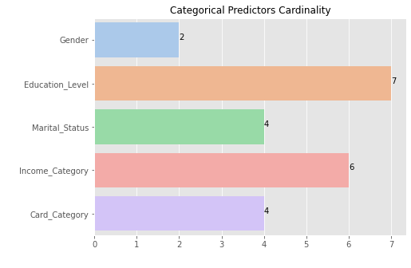

```python
fig, ax = plt.subplots(figsize=(7,5))
sns.barplot(x=cat_stat['unique'], y=cat_stat['feature'], orient='h')
ax.set_xlabel(' ')
ax.set_ylabel(' ')
ax.set_title('Categorical Predictors Cardinality', fontsize=12)
# add value labels
for j,v in enumerate(cat_stat['unique']):
    ax.text(v,j,str(v))
plt.show()
```

There's no problem in cardinality, as each features has relatively few unique value counts. Too much unique values on categorical features would cause problems in one-hot encoding, as we could end up having too many features.

##### 3.4.2.3. Distribution

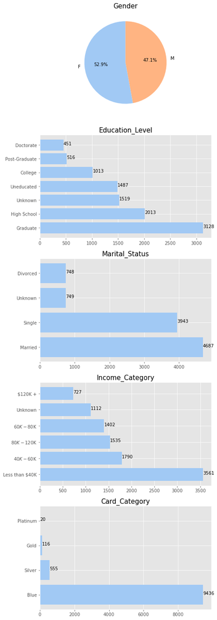

```python
# prepare the figure and axes
fig, ax = plt.subplots(ncols=1, nrows=5, figsize=(7,25))  #each axes size=7x5

i=0  # initialize i for iteration

# iterate plotting
for col in cat_pred:
    catcount = df[col].value_counts()
    catlabel = df[col].value_counts().index

    # for more than two unique values
    if len(df[col].value_counts()) > 2:
        # bar plot
        catcount = df[col].value_counts()
        catlabel = df[col].value_counts().index
        ax[i].barh(catlabel, catcount)
        # add value label
        for j,v in enumerate(catcount):
            ax[i].text(v,j,str(v))
            continue
        ax[i].set_title(col, fontsize=15)

    # for less than 2 unique values
    else:
        #pie plot
        ax[i].pie(catcount, labels=catlabel, autopct='%1.1f%%', startangle=90)
        ax[i].set_title(col, fontsize=15)

    i=i+1
```

##### 3.4.2.4. Categorical-Target Relationship

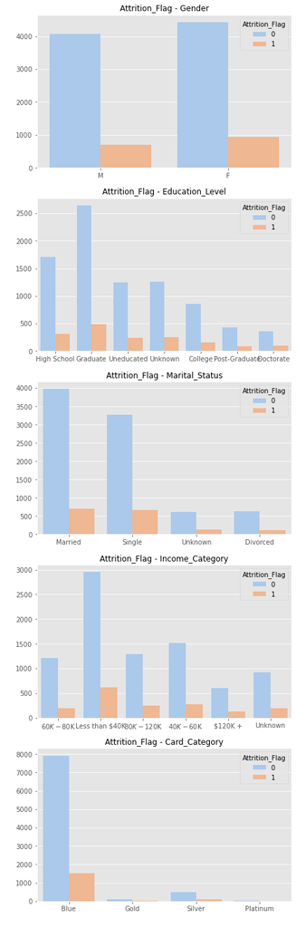

```python
fig, ax = plt.subplots(ncols=1, nrows=5, figsize=(7,25))  #each axes size=7x5

i=0

for col in cat_pred:
    sns.countplot(x=df[col], hue=df['Attrition_Flag'], fill=True, alpha=1, ax=ax[i])
    ax[i].set_xlabel(' ')
    ax[i].set_ylabel(' ')
    #ax[i].xaxis.set_ticks_params(labelsize=14)
    #ax[i].ticks_params(left=False, labelleft=False)
    #ax[i].set_ylabel(col, fontsize=16)
    #ax[i].bar_label(ax[i].containers[0], size='12')
    ax[i].set_title('Attrition_Flag - {}'.format(col), fontsize=12)
    # add value label
    #for j,v in enumerate(?):
    #    ax[i].text(v,j,str(v))
    #    continue
    i=i+1

plt.show()
```

### Stage 4 - Data Preprocessing

```python
# copy df to a new variable that will be processed
data = df
```

##### 4.1. Numerical Data Handling

##### 4.1.1. Outlier Removal

Outlier should be removed to clean our data. Previously, we have calculate the percentage of removed rows using two outlier methods:

```python
print('Inner Fence, rows removed: {}%'.format(round(removed_if, 2)))
print('Outer Fence, rows removed: {}%'.format(round(removed_of, 2)))
```

```
Inner Fence, rows removed: 32.84%
Outer Fence, rows removed: 8.77%
```

Removing too much rows would make our data not representative of the actual dataset. Normally, it should only be around 5% to 10%. Therefore, we will use the Outer Fence method to find and remove the outliers as it only remove 8.77% or the rows.

```python
# recall the outliers summary of Outer Fence method
outlier_df_of
```

|  | feature | outlier_count_of | unique_outlier_count_of |
| --- | --- | --- | --- |
| 0 | Customer_Age | 0 | 0 |
| 1 | Dependent_count | 0 | 0 |
| 2 | Months_on_book | 0 | 0 |
| 3 | Total_Relationship_Count | 0 | 0 |
| 4 | Months_Inactive_12_mon | 0 | 0 |
| 5 | Contacts_Count_12_mon | 0 | 0 |
| 6 | Credit_Limit | 0 | 0 |
| 7 | Total_Revolving_Bal | 0 | 0 |
| 8 | Avg_Open_To_Buy | 0 | 0 |
| 9 | Total_Amt_Chng_Q4_Q1 | 90 | 83 |
| 10 | Total_Trans_Amt | 737 | 667 |
| 11 | Total_Trans_Ct | 0 | 0 |
| 12 | Total_Ct_Chng_Q4_Q1 | 80 | 48 |
| 13 | Avg_Utilization_Ratio | 0 | 0 |

```python
# Remove outliers based on outer fence boundary
for col in num_pred:
    stats = data[col].describe()
    q1, q3 = stats['25%'], stats['75%']
    iqr = q3-q1
    lower_bound = q1 - (3 * iqr)
    upper_bound = q3 + (3 * iqr)

    data = data[(data[col] >= lower_bound) & (data[col] <= upper_bound)]

# Check updated dataframe
data.info()
```

```
<class 'pandas.core.frame.DataFrame'>
Int64Index: 9240 entries, 5 to 10126
Data columns (total 20 columns):
 #   Column                    Non-Null Count  Dtype
---  ------                    --------------  -----
 0   Attrition_Flag            9240 non-null   int64
 1   Customer_Age              9240 non-null   int64
 2   Gender                    9240 non-null   object
 3   Dependent_count           9240 non-null   int64
 4   Education_Level           9240 non-null   object
 5   Marital_Status            9240 non-null   object
 6   Income_Category           9240 non-null   object
 7   Card_Category             9240 non-null   object
 8   Months_on_book            9240 non-null   int64
 9   Total_Relationship_Count  9240 non-null   int64
 10  Months_Inactive_12_mon    9240 non-null   int64
 11  Contacts_Count_12_mon     9240 non-null   int64
 12  Credit_Limit              9240 non-null   float64
 13  Total_Revolving_Bal       9240 non-null   int64
 14  Avg_Open_To_Buy           9240 non-null   float64
 15  Total_Amt_Chng_Q4_Q1      9240 non-null   float64
 16  Total_Trans_Amt           9240 non-null   int64
 17  Total_Trans_Ct            9240 non-null   int64
 18  Total_Ct_Chng_Q4_Q1       9240 non-null   float64
 19  Avg_Utilization_Ratio     9240 non-null   float64
dtypes: float64(5), int64(10), object(5)
memory usage: 1.5+ MB
```

```python
# updated dataframe
data.shape
```

```
(9240, 20)
```

##### 4.1.2. Remove Highly Correlated Predictors

For two predictor features that are highly correlated, we just need one of them to be used on model as they are assumed to have similar predictive power. Let's recalculate their correlation:

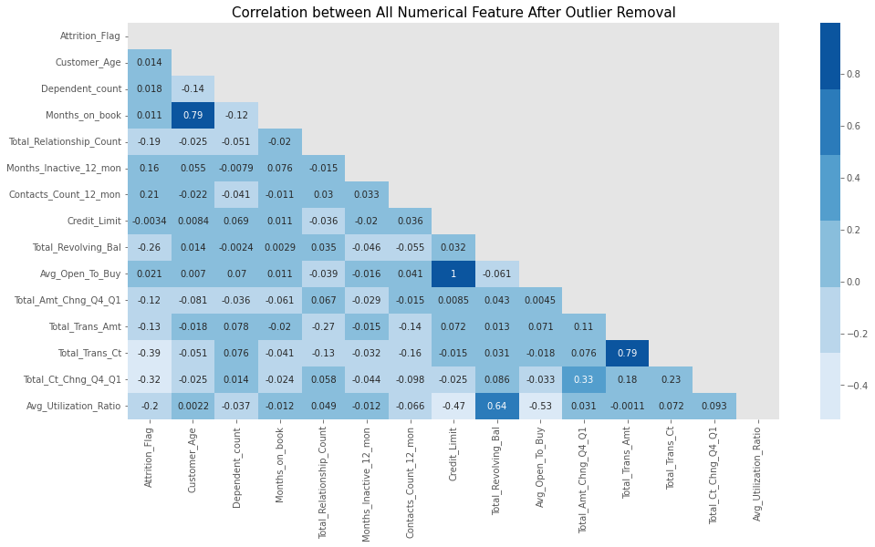

```python
### recalculate correlation after outlier removal
# prepare figure
plt.figure(figsize=(16,8))
plt.title('Correlation between All Numerical Feature After Outlier Removal', size=15)

# create mask to cover the upper triangle of the heatmap
mask = np.triu(np.ones_like(data.corr()))
# create colormap
colormap = sns.color_palette("Blues")
# plot heatmap
sns.heatmap(data.corr(), annot=True, cmap=colormap, mask=mask)


plt.show()
```

Avg_Open_To_Buy and Credit_Limit are highly correlated (1). It means that an increase on one would increase the other, so we only need one of them and we can safely drop the other. We choose to drop one features that have higher correlation to target variabel Attrition_Flag, that is Avg_Open_To_Buy (0.021 vs -0.0034)

```python
# drop one of the highly correlated feature
dropped = ['Avg_Open_To_Buy']
data = data.drop(dropped, axis=1)

# updated DataFrame
data.info()
```

```
<class 'pandas.core.frame.DataFrame'>
Int64Index: 9240 entries, 5 to 10126
Data columns (total 19 columns):
 #   Column                    Non-Null Count  Dtype
---  ------                    --------------  -----
 0   Attrition_Flag            9240 non-null   int64
 1   Customer_Age              9240 non-null   int64
 2   Gender                    9240 non-null   object
 3   Dependent_count           9240 non-null   int64
 4   Education_Level           9240 non-null   object
 5   Marital_Status            9240 non-null   object
 6   Income_Category           9240 non-null   object
 7   Card_Category             9240 non-null   object
 8   Months_on_book            9240 non-null   int64
 9   Total_Relationship_Count  9240 non-null   int64
 10  Months_Inactive_12_mon    9240 non-null   int64
 11  Contacts_Count_12_mon     9240 non-null   int64
 12  Credit_Limit              9240 non-null   float64
 13  Total_Revolving_Bal       9240 non-null   int64
 14  Total_Amt_Chng_Q4_Q1      9240 non-null   float64
 15  Total_Trans_Amt           9240 non-null   int64
 16  Total_Trans_Ct            9240 non-null   int64
 17  Total_Ct_Chng_Q4_Q1       9240 non-null   float64
 18  Avg_Utilization_Ratio     9240 non-null   float64
dtypes: float64(4), int64(10), object(5)
memory usage: 1.4+ MB
```

```python
# redefine numerical predictors list by removing dropped features
### 1st way
#num_pred_process = num_pred
#for i in dropped:
#    num_pred_process.remove(i)
### 2nd way
num_pred_process = [x for x in num_pred if x not in dropped]

print(*num_pred_process, sep='\n')
print('\nCount:', len(num_pred_process))
```

```
Customer_Age
Dependent_count
Months_on_book
Total_Relationship_Count
Months_Inactive_12_mon
Contacts_Count_12_mon
Credit_Limit
Total_Revolving_Bal
Total_Amt_Chng_Q4_Q1
Total_Trans_Amt
Total_Trans_Ct
Total_Ct_Chng_Q4_Q1
Avg_Utilization_Ratio

Count: 13
```

##### 4.1.3. Scaling

The technique used to scale numerical data depends on the type of its distribution.

NOTE: Normally in the actual project it's either Standardization or Normalization, as using both method would add additional works.

```python
# check skewness of updated dataframe
skew_upd = []
for col in num_pred_process:
    skew_upd.append(round(data[col].skew(),3))

num_dist_upd = pd.DataFrame({'feature':num_pred_process, 'skewness':skew_upd})
num_dist_upd
```

|  | feature | skewness |
| --- | --- | --- |
| 0 | Customer_Age | -0.02600 |
| 1 | Dependent_count | -0.03400 |
| 2 | Months_on_book | -0.09000 |
| 3 | Total_Relationship_Count | -0.23100 |
| 4 | Months_Inactive_12_mon | 0.62300 |
| 5 | Contacts_Count_12_mon | -0.01000 |
| 6 | Credit_Limit | 1.77000 |
| 7 | Total_Revolving_Bal | -0.11200 |
| 8 | Total_Amt_Chng_Q4_Q1 | 0.57100 |
| 9 | Total_Trans_Amt | 0.94100 |
| 10 | Total_Trans_Ct | -0.26400 |
| 11 | Total_Ct_Chng_Q4_Q1 | 0.32100 |
| 12 | Avg_Utilization_Ratio | 0.66800 |

Features that have skewness between -0.05 and 0.05 are assumed to have gaussian distribution, which are:

```python
std_pred = list(num_dist.query('skewness < 0.05 & skewness > -0.05')['feature'])
std_pred
```

```
['Customer_Age', 'Dependent_count', 'Contacts_Count_12_mon']
```

```python
# import required libraries
from sklearn.preprocessing import StandardScaler, MinMaxScaler
```

##### 4.1.3.1. Standardization

```python
# feature to be standardized
std_pred
```

```
['Customer_Age', 'Dependent_count', 'Contacts_Count_12_mon']
```

Standardization is used to scale features that are assumed to have gaussian distribution (skewness between -0.05 and 0.05), which are:

```python
# scaler
std_scaler = StandardScaler()
std_scaler.fit(data[std_pred])
data[std_pred] = std_scaler.transform(data[std_pred])
```

```python
data[std_pred].describe()
```

|  | Customer_Age | Dependent_count | Contacts_Count_12_mon |
| --- | --- | --- | --- |
| count | 9240.00000 | 9240.00000 | 9240.00000 |
| mean | -0.00000 | -0.00000 | 0.00000 |
| std | 1.00005 | 1.00005 | 1.00005 |
| min | -2.56098 | -1.81291 | -2.22176 |
| 25% | -0.67960 | -1.04235 | -0.42671 |
| 50% | -0.05248 | -0.27178 | 0.47081 |
| 75% | 0.70007 | 0.49878 | 0.47081 |
| max | 2.95773 | 2.03991 | 3.16338 |

##### 4.1.3.2. Normalization

If the data doesn't have a gaussian distribution, use Normalization

```python
# define features to be normalized
mm_pred = num_pred_process
for i in std_pred:
    mm_pred.remove(i)
mm_pred
```

```
['Months_on_book',
 'Total_Relationship_Count',
 'Months_Inactive_12_mon',
 'Credit_Limit',
 'Total_Revolving_Bal',
 'Total_Amt_Chng_Q4_Q1',
 'Total_Trans_Amt',
 'Total_Trans_Ct',
 'Total_Ct_Chng_Q4_Q1',
 'Avg_Utilization_Ratio']
```

```python
# scaler
mm_scaler = MinMaxScaler()
mm_scaler.fit(data[mm_pred])
data[mm_pred] = mm_scaler.transform(data[mm_pred])
```

```python
data[mm_pred].describe()
```

|  | Months_on_book | Total_Relationship_Count | Months_Inactive_12_mon | Credit_Limit | Total_Revolving_Bal | Total_Amt_Chng_Q4_Q1 | Total_Trans_Amt | Total_Trans_Ct | Total_Ct_Chng_Q4_Q1 | Avg_Utilization_Ratio |
| --- | --- | --- | --- | --- | --- | --- | --- | --- | --- | --- |
| count | 9240.00000 | 9240.00000 | 9240.00000 | 9240.00000 | 9240.00000 | 9240.00000 | 9240.00000 | 9240.00000 | 9240.00000 | 9240.00000 |
| mean | 0.53495 | 0.58429 | 0.39230 | 0.20439 | 0.45362 | 0.48415 | 0.25957 | 0.46166 | 0.45051 | 0.28183 |
| std | 0.18519 | 0.30428 | 0.16878 | 0.26625 | 0.32551 | 0.12666 | 0.15212 | 0.17912 | 0.13468 | 0.28062 |
| min | 0.00000 | 0.00000 | 0.00000 | 0.00000 | 0.00000 | 0.00000 | 0.00000 | 0.00000 | 0.00000 | 0.00000 |
| 25% | 0.44186 | 0.40000 | 0.33333 | 0.03113 | 0.00000 | 0.40337 | 0.13313 | 0.30357 | 0.36764 | 0.00000 |
| 50% | 0.53488 | 0.60000 | 0.33333 | 0.08515 | 0.49781 | 0.47341 | 0.27068 | 0.49107 | 0.44790 | 0.18418 |
| 75% | 0.62791 | 0.80000 | 0.50000 | 0.26301 | 0.70163 | 0.55447 | 0.33878 | 0.60714 | 0.52686 | 0.52052 |
| max | 1.00000 | 1.00000 | 1.00000 | 1.00000 | 1.00000 | 1.00000 | 1.00000 | 1.00000 | 1.00000 | 1.00000 |

##### 4.2. Categorical Data Handling

ML models cannot understand categorical data type, thus we need to encode the categorical value into numerical.

##### 4.2.1. Label Encoding

Ordinal and binary data are encoded with Label Encoding, which encodes their value into a range of integer starting from 0. Note that on Card_Category, the count for 'Platinum' and 'Gold' are relatively small. Thus, we shall merge them with Card_Category 'Silver'

```python
# Encode Education_Level
data['Education_Level'] = data['Education_Level'].map({'Unknown':0,
                                                       'Uneducated':1,
                                                       'High School':2,
                                                       'College':3,
                                                       'Graduate':4,
                                                       'Post-Graduate':5,
                                                       'Doctorate':6})
```

```python
# Encode Income_Category
data['Income_Category'] = data['Income_Category'].map({'Unknown':0,
                                                       'Less than $40K':1,
                                                       '$40K - $60K':2,
                                                       '$60K - $80K':3,
                                                       '$80K - $120K':4,
                                                       '$120K +':5})
```

```python
# Encode Card_Category
data['Card_Category'] = data['Card_Category'].map({'Blue':0,
                                                   'Silver': 1,
                                                   'Gold':1,
                                                   'Platinum':1})
```

```python
data.head(150)
```

|  | Attrition_Flag | Customer_Age | Gender | Dependent_count | Education_Level | Marital_Status | Income_Category | Card_Category | Months_on_book | Total_Relationship_Count | Months_Inactive_12_mon | Contacts_Count_12_mon | Credit_Limit | Total_Revolving_Bal | Total_Amt_Chng_Q4_Q1 | Total_Trans_Amt | Total_Trans_Ct | Total_Ct_Chng_Q4_Q1 | Avg_Utilization_Ratio |
| --- | --- | --- | --- | --- | --- | --- | --- | --- | --- | --- | --- | --- | --- | --- | --- | --- | --- | --- | --- |
| 5 | 0 | -0.30333 | M | -0.27178 | 4 | Married | 2 | 0 | 0.53488 | 0.40000 | 0.16667 | -0.42671 | 0.07775 | 0.49543 | 0.89235 | 0.04825 | 0.12500 | 0.54757 | 0.31131 |
| 9 | 0 | 0.19837 | M | -0.27178 | 4 | Single | 4 | 0 | 0.53488 | 1.00000 | 0.50000 | 0.47081 | 0.30890 | 0.66627 | 0.98833 | 0.07772 | 0.19643 | 0.57087 | 0.14414 |
| 10 | 0 | -0.55418 | M | 2.03991 | 1 | Unknown | 5 | 0 | 0.41860 | 0.80000 | 0.50000 | -0.42671 | 0.16052 | 0.58284 | 0.53891 | 0.05768 | 0.28571 | 0.44013 | 0.21722 |
| 11 | 0 | 2.33060 | M | -1.04235 | 0 | Married | 2 | 0 | 0.95349 | 1.00000 | 0.33333 | 0.47081 | 0.23148 | 0.63051 | 0.92931 | 0.06712 | 0.14286 | 0.88285 | 0.17417 |
| 14 | 0 | 1.32720 | F | -0.27178 | 4 | Married | 1 | 0 | 0.81395 | 0.80000 | 0.33333 | -0.42671 | 0.03016 | 0.27016 | 0.77173 | 0.08849 | 0.16964 | 0.39547 | 0.27928 |
| 19 | 0 | -0.17790 | F | -0.27178 | 4 | Married | 0 | 0 | 0.55814 | 1.00000 | 0.16667 | -0.42671 | 0.39397 | 0.45967 | 0.62646 | 0.05819 | 0.09821 | 0.58835 | 0.08008 |
| 20 | 0 | 0.07295 | M | -1.04235 | 6 | Divorced | 3 | 0 | 0.67442 | 0.80000 | 0.33333 | -2.22176 | 0.59075 | 0.71514 | 0.58755 | 0.05576 | 0.15179 | 0.60129 | 0.08609 |
| 21 | 1 | 1.95433 | F | -1.81291 | 4 | Married | 1 | 0 | 0.83721 | 0.20000 | 0.50000 | 0.47081 | 0.00000 | 0.00000 | 0.67899 | 0.01519 | 0.05357 | 0.38835 | 0.00000 |
| 23 | 0 | 0.07295 | F | 1.26935 | 0 | Single | 1 | 0 | 0.53488 | 0.40000 | 0.50000 | -0.42671 | 0.03186 | 0.61979 | 0.37160 | 0.05142 | 0.11607 | 0.22848 | 0.62663 |
| 24 | 0 | 0.95092 | M | -0.27178 | 0 | Married | 4 | 0 | 0.67442 | 0.60000 | 0.33333 | 0.47081 | 0.32586 | 0.00000 | 0.69715 | 0.05009 | 0.09821 | 0.48544 | 0.00000 |
| 25 | 0 | -0.67960 | F | 0.49878 | 4 | Single | 1 | 0 | 0.34884 | 1.00000 | 0.16667 | -0.42671 | 0.19136 | 0.66309 | 0.51686 | 0.04516 | 0.10714 | 0.53916 | 0.21522 |
| 26 | 0 | 1.57805 | M | -1.04235 | 2 | Unknown | 2 | 0 | 0.76744 | 0.60000 | 0.16667 | -0.42671 | 0.40347 | 0.54589 | 0.59728 | 0.05735 | 0.11607 | 0.84142 | 0.09309 |
| 27 | 0 | 2.07975 | M | -1.04235 | 0 | Married | 3 | 0 | 1.00000 | 0.40000 | 0.50000 | -0.42671 | 0.26534 | 0.40127 | 0.54669 | 0.11637 | 0.26786 | 0.64725 | 0.09910 |
| 29 | 0 | 0.07295 | M | 1.26935 | 2 | Married | 2 | 0 | 0.67442 | 1.00000 | 0.00000 | -2.22176 | 0.10118 | 0.54112 | 0.47925 | 0.04466 | 0.25000 | 0.58252 | 0.28529 |
| 34 | 0 | 1.45263 | M | -1.81291 | 4 | Married | 4 | 0 | 0.83721 | 1.00000 | 0.33333 | -0.42671 | 0.33608 | 0.67382 | 0.33658 | 0.06520 | 0.12500 | 0.46214 | 0.13514 |
| 35 | 0 | 1.07635 | F | -1.04235 | 3 | Single | 1 | 0 | 0.53488 | 0.60000 | 0.33333 | -1.32424 | 0.06293 | 0.76043 | 0.33074 | 0.07488 | 0.29464 | 0.31262 | 0.54454 |
| 37 | 0 | -0.55418 | F | 1.26935 | 2 | Married | 1 | 1 | 0.53488 | 0.20000 | 0.50000 | 0.47081 | 0.42309 | 0.00000 | 0.56096 | 0.03807 | 0.10714 | 0.77670 | 0.00000 |
| 38 | 0 | 1.32720 | F | -1.04235 | 4 | Unknown | 2 | 0 | 0.83721 | 0.40000 | 0.50000 | -0.42671 | 0.06753 | 0.35201 | 0.85603 | 0.07964 | 0.16071 | 0.35987 | 0.24124 |
| 39 | 1 | 2.45603 | F | -1.81291 | 6 | Married | 0 | 0 | 1.00000 | 0.80000 | 0.66667 | 0.47081 | 0.19480 | 0.24037 | 0.68223 | 0.01620 | 0.05357 | 0.09256 | 0.07708 |
| 40 | 0 | -0.17790 | M | 0.49878 | 4 | Single | 4 | 0 | 0.65116 | 0.20000 | 0.33333 | -0.42671 | 0.93682 | 0.22964 | 0.67575 | 0.05000 | 0.16071 | 0.30680 | 0.01802 |
| 41 | 0 | 0.57465 | M | -0.27178 | 0 | Married | 2 | 0 | 0.72093 | 0.60000 | 0.16667 | -2.22176 | 0.14411 | 0.87565 | 0.52075 | 0.06987 | 0.16071 | 0.35987 | 0.35536 |
| 42 | 0 | 0.44922 | F | -1.04235 | 3 | Single | 2 | 1 | 0.69767 | 0.40000 | 0.33333 | 0.47081 | 0.47965 | 1.00000 | 0.93969 | 0.10402 | 0.20536 | 0.77670 | 0.14515 |
| 43 | 0 | 0.32380 | M | 0.49878 | 2 | Married | 3 | 0 | 0.55814 | 0.80000 | 0.33333 | -1.32424 | 0.07460 | 0.00000 | 0.78729 | 0.10402 | 0.19643 | 0.64725 | 0.00000 |
| 44 | 0 | -1.05588 | F | 1.26935 | 4 | Single | 0 | 0 | 0.34884 | 0.20000 | 0.50000 | 0.47081 | 0.25370 | 0.81645 | 0.63359 | 0.04441 | 0.11607 | 0.59353 | 0.20921 |
| 48 | 0 | -0.05248 | M | 0.49878 | 2 | Married | 4 | 0 | 0.62791 | 0.60000 | 0.50000 | 0.47081 | 0.54477 | 0.57012 | 0.51038 | 0.05902 | 0.15179 | 0.51780 | 0.07407 |
| 49 | 0 | 0.70007 | M | -1.04235 | 3 | Single | 4 | 0 | 0.62791 | 0.80000 | 0.16667 | -1.32424 | 0.09997 | 0.48749 | 0.40467 | 0.05259 | 0.26786 | 0.38835 | 0.25926 |
| 50 | 0 | 0.70007 | F | 0.49878 | 0 | Married | 1 | 0 | 0.65116 | 1.00000 | 0.50000 | -0.42671 | 0.03579 | 0.61542 | 0.85668 | 0.11420 | 0.17857 | 0.73981 | 0.59159 |
| 51 | 1 | 0.95092 | F | -1.04235 | 4 | Married | 1 | 0 | 0.62791 | 0.20000 | 0.50000 | -1.32424 | 0.00000 | 0.32102 | 0.64656 | 0.01628 | 0.08036 | 0.58252 | 0.56256 |
| 53 | 0 | 0.32380 | M | -0.27178 | 0 | Married | 5 | 0 | 0.53488 | 0.60000 | 0.33333 | -2.22176 | 0.55399 | 1.00000 | 0.43061 | 0.07547 | 0.22321 | 0.16181 | 0.12713 |
| 54 | 1 | 1.20178 | M | -0.27178 | 4 | Married | 5 | 0 | 0.53488 | 0.00000 | 0.50000 | 0.47081 | 0.43324 | 0.00000 | 0.67510 | 0.00768 | 0.04464 | 0.23560 | 0.00000 |

[output cut: 120 more lines]

##### 4.2.2. One Hot Encoding

Gender and Marital_Status cannot be ordered like ordinal, thus we encode them by using One Hot Encoding using Pandas library.

```python
# Encode Gender and Marital_Status
data = pd.get_dummies(data, columns=['Gender', 'Marital_Status'], drop_first=False)
```

```python
data.head(50)
```

|  | Attrition_Flag | Customer_Age | Dependent_count | Education_Level | Income_Category | Card_Category | Months_on_book | Total_Relationship_Count | Months_Inactive_12_mon | Contacts_Count_12_mon | Credit_Limit | Total_Revolving_Bal | Total_Amt_Chng_Q4_Q1 | Total_Trans_Amt | Total_Trans_Ct | Total_Ct_Chng_Q4_Q1 | Avg_Utilization_Ratio | Gender_F | Gender_M | Marital_Status_Divorced | Marital_Status_Married | Marital_Status_Single | Marital_Status_Unknown |
| --- | --- | --- | --- | --- | --- | --- | --- | --- | --- | --- | --- | --- | --- | --- | --- | --- | --- | --- | --- | --- | --- | --- | --- |
| 5 | 0 | -0.30333 | -0.27178 | 4 | 2 | 0 | 0.53488 | 0.40000 | 0.16667 | -0.42671 | 0.07775 | 0.49543 | 0.89235 | 0.04825 | 0.12500 | 0.54757 | 0.31131 | 0 | 1 | 0 | 1 | 0 | 0 |
| 9 | 0 | 0.19837 | -0.27178 | 4 | 4 | 0 | 0.53488 | 1.00000 | 0.50000 | 0.47081 | 0.30890 | 0.66627 | 0.98833 | 0.07772 | 0.19643 | 0.57087 | 0.14414 | 0 | 1 | 0 | 0 | 1 | 0 |
| 10 | 0 | -0.55418 | 2.03991 | 1 | 5 | 0 | 0.41860 | 0.80000 | 0.50000 | -0.42671 | 0.16052 | 0.58284 | 0.53891 | 0.05768 | 0.28571 | 0.44013 | 0.21722 | 0 | 1 | 0 | 0 | 0 | 1 |
| 11 | 0 | 2.33060 | -1.04235 | 0 | 2 | 0 | 0.95349 | 1.00000 | 0.33333 | 0.47081 | 0.23148 | 0.63051 | 0.92931 | 0.06712 | 0.14286 | 0.88285 | 0.17417 | 0 | 1 | 0 | 1 | 0 | 0 |
| 14 | 0 | 1.32720 | -0.27178 | 4 | 1 | 0 | 0.81395 | 0.80000 | 0.33333 | -0.42671 | 0.03016 | 0.27016 | 0.77173 | 0.08849 | 0.16964 | 0.39547 | 0.27928 | 1 | 0 | 0 | 1 | 0 | 0 |
| 19 | 0 | -0.17790 | -0.27178 | 4 | 0 | 0 | 0.55814 | 1.00000 | 0.16667 | -0.42671 | 0.39397 | 0.45967 | 0.62646 | 0.05819 | 0.09821 | 0.58835 | 0.08008 | 1 | 0 | 0 | 1 | 0 | 0 |
| 20 | 0 | 0.07295 | -1.04235 | 6 | 3 | 0 | 0.67442 | 0.80000 | 0.33333 | -2.22176 | 0.59075 | 0.71514 | 0.58755 | 0.05576 | 0.15179 | 0.60129 | 0.08609 | 0 | 1 | 1 | 0 | 0 | 0 |
| 21 | 1 | 1.95433 | -1.81291 | 4 | 1 | 0 | 0.83721 | 0.20000 | 0.50000 | 0.47081 | 0.00000 | 0.00000 | 0.67899 | 0.01519 | 0.05357 | 0.38835 | 0.00000 | 1 | 0 | 0 | 1 | 0 | 0 |
| 23 | 0 | 0.07295 | 1.26935 | 0 | 1 | 0 | 0.53488 | 0.40000 | 0.50000 | -0.42671 | 0.03186 | 0.61979 | 0.37160 | 0.05142 | 0.11607 | 0.22848 | 0.62663 | 1 | 0 | 0 | 0 | 1 | 0 |
| 24 | 0 | 0.95092 | -0.27178 | 0 | 4 | 0 | 0.67442 | 0.60000 | 0.33333 | 0.47081 | 0.32586 | 0.00000 | 0.69715 | 0.05009 | 0.09821 | 0.48544 | 0.00000 | 0 | 1 | 0 | 1 | 0 | 0 |
| 25 | 0 | -0.67960 | 0.49878 | 4 | 1 | 0 | 0.34884 | 1.00000 | 0.16667 | -0.42671 | 0.19136 | 0.66309 | 0.51686 | 0.04516 | 0.10714 | 0.53916 | 0.21522 | 1 | 0 | 0 | 0 | 1 | 0 |
| 26 | 0 | 1.57805 | -1.04235 | 2 | 2 | 0 | 0.76744 | 0.60000 | 0.16667 | -0.42671 | 0.40347 | 0.54589 | 0.59728 | 0.05735 | 0.11607 | 0.84142 | 0.09309 | 0 | 1 | 0 | 0 | 0 | 1 |
| 27 | 0 | 2.07975 | -1.04235 | 0 | 3 | 0 | 1.00000 | 0.40000 | 0.50000 | -0.42671 | 0.26534 | 0.40127 | 0.54669 | 0.11637 | 0.26786 | 0.64725 | 0.09910 | 0 | 1 | 0 | 1 | 0 | 0 |
| 29 | 0 | 0.07295 | 1.26935 | 2 | 2 | 0 | 0.67442 | 1.00000 | 0.00000 | -2.22176 | 0.10118 | 0.54112 | 0.47925 | 0.04466 | 0.25000 | 0.58252 | 0.28529 | 0 | 1 | 0 | 1 | 0 | 0 |
| 34 | 0 | 1.45263 | -1.81291 | 4 | 4 | 0 | 0.83721 | 1.00000 | 0.33333 | -0.42671 | 0.33608 | 0.67382 | 0.33658 | 0.06520 | 0.12500 | 0.46214 | 0.13514 | 0 | 1 | 0 | 1 | 0 | 0 |
| 35 | 0 | 1.07635 | -1.04235 | 3 | 1 | 0 | 0.53488 | 0.60000 | 0.33333 | -1.32424 | 0.06293 | 0.76043 | 0.33074 | 0.07488 | 0.29464 | 0.31262 | 0.54454 | 1 | 0 | 0 | 0 | 1 | 0 |
| 37 | 0 | -0.55418 | 1.26935 | 2 | 1 | 1 | 0.53488 | 0.20000 | 0.50000 | 0.47081 | 0.42309 | 0.00000 | 0.56096 | 0.03807 | 0.10714 | 0.77670 | 0.00000 | 1 | 0 | 0 | 1 | 0 | 0 |
| 38 | 0 | 1.32720 | -1.04235 | 4 | 2 | 0 | 0.83721 | 0.40000 | 0.50000 | -0.42671 | 0.06753 | 0.35201 | 0.85603 | 0.07964 | 0.16071 | 0.35987 | 0.24124 | 1 | 0 | 0 | 0 | 0 | 1 |
| 39 | 1 | 2.45603 | -1.81291 | 6 | 0 | 0 | 1.00000 | 0.80000 | 0.66667 | 0.47081 | 0.19480 | 0.24037 | 0.68223 | 0.01620 | 0.05357 | 0.09256 | 0.07708 | 1 | 0 | 0 | 1 | 0 | 0 |
| 40 | 0 | -0.17790 | 0.49878 | 4 | 4 | 0 | 0.65116 | 0.20000 | 0.33333 | -0.42671 | 0.93682 | 0.22964 | 0.67575 | 0.05000 | 0.16071 | 0.30680 | 0.01802 | 0 | 1 | 0 | 0 | 1 | 0 |
| 41 | 0 | 0.57465 | -0.27178 | 0 | 2 | 0 | 0.72093 | 0.60000 | 0.16667 | -2.22176 | 0.14411 | 0.87565 | 0.52075 | 0.06987 | 0.16071 | 0.35987 | 0.35536 | 0 | 1 | 0 | 1 | 0 | 0 |
| 42 | 0 | 0.44922 | -1.04235 | 3 | 2 | 1 | 0.69767 | 0.40000 | 0.33333 | 0.47081 | 0.47965 | 1.00000 | 0.93969 | 0.10402 | 0.20536 | 0.77670 | 0.14515 | 1 | 0 | 0 | 0 | 1 | 0 |
| 43 | 0 | 0.32380 | 0.49878 | 2 | 3 | 0 | 0.55814 | 0.80000 | 0.33333 | -1.32424 | 0.07460 | 0.00000 | 0.78729 | 0.10402 | 0.19643 | 0.64725 | 0.00000 | 0 | 1 | 0 | 1 | 0 | 0 |
| 44 | 0 | -1.05588 | 1.26935 | 4 | 0 | 0 | 0.34884 | 0.20000 | 0.50000 | 0.47081 | 0.25370 | 0.81645 | 0.63359 | 0.04441 | 0.11607 | 0.59353 | 0.20921 | 1 | 0 | 0 | 0 | 1 | 0 |
| 48 | 0 | -0.05248 | 0.49878 | 2 | 4 | 0 | 0.62791 | 0.60000 | 0.50000 | 0.47081 | 0.54477 | 0.57012 | 0.51038 | 0.05902 | 0.15179 | 0.51780 | 0.07407 | 0 | 1 | 0 | 1 | 0 | 0 |
| 49 | 0 | 0.70007 | -1.04235 | 3 | 4 | 0 | 0.62791 | 0.80000 | 0.16667 | -1.32424 | 0.09997 | 0.48749 | 0.40467 | 0.05259 | 0.26786 | 0.38835 | 0.25926 | 0 | 1 | 0 | 0 | 1 | 0 |
| 50 | 0 | 0.70007 | 0.49878 | 0 | 1 | 0 | 0.65116 | 1.00000 | 0.50000 | -0.42671 | 0.03579 | 0.61542 | 0.85668 | 0.11420 | 0.17857 | 0.73981 | 0.59159 | 1 | 0 | 0 | 1 | 0 | 0 |
| 51 | 1 | 0.95092 | -1.04235 | 4 | 1 | 0 | 0.62791 | 0.20000 | 0.50000 | -1.32424 | 0.00000 | 0.32102 | 0.64656 | 0.01628 | 0.08036 | 0.58252 | 0.56256 | 1 | 0 | 0 | 1 | 0 | 0 |
| 53 | 0 | 0.32380 | -0.27178 | 0 | 5 | 0 | 0.53488 | 0.60000 | 0.33333 | -2.22176 | 0.55399 | 1.00000 | 0.43061 | 0.07547 | 0.22321 | 0.16181 | 0.12713 | 0 | 1 | 0 | 1 | 0 | 0 |
| 54 | 1 | 1.20178 | -0.27178 | 4 | 5 | 0 | 0.53488 | 0.00000 | 0.50000 | 0.47081 | 0.43324 | 0.00000 | 0.67510 | 0.00768 | 0.04464 | 0.23560 | 0.00000 | 0 | 1 | 0 | 1 | 0 | 0 |
| 55 | 0 | 0.32380 | 1.26935 | 4 | 1 | 0 | 0.53488 | 1.00000 | 0.66667 | -0.42671 | 0.05622 | 0.87406 | 0.43969 | 0.04525 | 0.19643 | 0.38835 | 0.66767 | 1 | 0 | 0 | 0 | 0 | 1 |
| 56 | 0 | 0.32380 | 0.49878 | 4 | 1 | 0 | 0.53488 | 0.20000 | 0.33333 | -2.22176 | 0.04123 | 0.93882 | 0.48638 | 0.06553 | 0.26786 | 0.38835 | 0.84384 | 1 | 0 | 0 | 0 | 1 | 0 |
| 57 | 0 | 1.20178 | -0.27178 | 1 | 2 | 0 | 0.86047 | 0.60000 | 0.33333 | 0.47081 | 0.09129 | 0.74692 | 0.71790 | 0.07630 | 0.16964 | 0.91715 | 0.42242 | 0 | 1 | 0 | 1 | 0 | 0 |
| 59 | 0 | -0.55418 | -0.27178 | 2 | 3 | 0 | 0.48837 | 0.60000 | 0.66667 | 0.47081 | 0.05737 | 0.69646 | 0.44747 | 0.05493 | 0.15179 | 0.80906 | 0.52553 | 0 | 1 | 0 | 0 | 1 | 0 |
| 60 | 0 | 1.07635 | 0.49878 | 0 | 4 | 0 | 0.79070 | 0.60000 | 0.33333 | 0.47081 | 0.06039 | 0.80095 | 0.58431 | 0.04900 | 0.20536 | 0.53916 | 0.58759 | 0 | 1 | 0 | 1 | 0 | 0 |
| 61 | 1 | 0.19837 | -0.27178 | 4 | 3 | 1 | 0.51163 | 0.20000 | 0.66667 | 1.36834 | 1.00000 | 0.00000 | 0.49481 | 0.01511 | 0.04464 | 0.32362 | 0.00000 | 0 | 1 | 0 | 1 | 0 | 0 |
| 62 | 0 | -0.93045 | -1.04235 | 2 | 3 | 0 | 0.46512 | 0.80000 | 0.50000 | 0.47081 | 0.13567 | 0.49702 | 0.61219 | 0.06728 | 0.16071 | 0.74693 | 0.21121 | 0 | 1 | 1 | 0 | 0 | 0 |
| 63 | 0 | -0.30333 | 1.26935 | 5 | 5 | 0 | 0.44186 | 0.20000 | 0.66667 | -0.42671 | 0.68078 | 0.83512 | 0.64656 | 0.06395 | 0.14286 | 0.47443 | 0.08809 | 0 | 1 | 0 | 0 | 1 | 0 |
| 64 | 0 | 0.82550 | -0.27178 | 2 | 5 | 0 | 0.72093 | 0.60000 | 0.33333 | -0.42671 | 0.40195 | 0.64919 | 0.64137 | 0.06503 | 0.11607 | 0.59353 | 0.11111 | 0 | 1 | 0 | 0 | 1 | 0 |
| 65 | 0 | 0.57465 | 1.26935 | 1 | 4 | 1 | 0.58140 | 0.60000 | 0.16667 | 1.36834 | 1.00000 | 0.60191 | 0.38392 | 0.06536 | 0.19643 | 0.38835 | 0.04404 | 0 | 1 | 0 | 0 | 1 | 0 |
| 66 | 0 | 1.32720 | -0.27178 | 3 | 3 | 0 | 0.90698 | 0.80000 | 0.50000 | 0.47081 | 0.15556 | 0.72189 | 0.40208 | 0.07037 | 0.22321 | 0.43172 | 0.27628 | 0 | 1 | 0 | 1 | 0 | 0 |
| 67 | 0 | -0.30333 | -0.27178 | 1 | 1 | 0 | 0.16279 | 1.00000 | 0.50000 | 0.47081 | 0.01952 | 0.58323 | 0.65110 | 0.05192 | 0.16071 | 0.35987 | 0.70470 | 1 | 0 | 0 | 0 | 1 | 0 |
| 70 | 0 | 0.57465 | 1.26935 | 4 | 5 | 0 | 0.67442 | 0.40000 | 0.33333 | 0.47081 | 1.00000 | 0.70044 | 0.82101 | 0.08682 | 0.27679 | 0.67961 | 0.05105 | 0 | 1 | 0 | 0 | 1 | 0 |
| 71 | 0 | 1.07635 | -0.27178 | 4 | 1 | 0 | 0.67442 | 0.80000 | 0.50000 | 0.47081 | 0.02351 | 0.41081 | 0.49157 | 0.08598 | 0.23214 | 0.18511 | 0.46747 | 1 | 0 | 0 | 1 | 0 | 0 |
| 72 | 0 | 0.95092 | -1.04235 | 4 | 3 | 0 | 0.69767 | 0.60000 | 0.33333 | 0.47081 | 0.04449 | 0.80652 | 0.49870 | 0.06228 | 0.09821 | 0.25890 | 0.69870 | 0 | 1 | 0 | 0 | 0 | 1 |
| 73 | 0 | -0.55418 | 2.03991 | 1 | 4 | 0 | 0.55814 | 1.00000 | 0.33333 | -0.42671 | 0.64922 | 0.60707 | 0.26848 | 0.07380 | 0.22321 | 0.33786 | 0.06707 | 0 | 1 | 0 | 1 | 0 | 0 |
| 74 | 0 | -0.30333 | -1.04235 | 3 | 3 | 0 | 0.51163 | 0.40000 | 0.50000 | 0.47081 | 0.69151 | 0.76758 | 0.85084 | 0.06937 | 0.12500 | 0.76505 | 0.07908 | 0 | 1 | 0 | 0 | 1 | 0 |
| 75 | 0 | 0.82550 | -0.27178 | 4 | 4 | 0 | 0.53488 | 0.80000 | 0.50000 | -0.42671 | 0.11590 | 0.60191 | 0.55577 | 0.06503 | 0.20536 | 0.28155 | 0.28729 | 0 | 1 | 0 | 0 | 1 | 0 |
| 77 | 0 | -1.18131 | 0.49878 | 1 | 1 | 0 | 0.37209 | 0.60000 | 0.66667 | -0.42671 | 0.16929 | 0.71553 | 0.48703 | 0.15268 | 0.41964 | 0.62524 | 0.25626 | 1 | 0 | 0 | 0 | 1 | 0 |
| 78 | 0 | 0.32380 | 0.49878 | 4 | 3 | 0 | 0.39535 | 1.00000 | 0.16667 | -0.42671 | 0.03319 | 0.72427 | 0.45590 | 0.07997 | 0.11607 | 0.22848 | 0.71972 | 0 | 1 | 1 | 0 | 0 | 0 |

### 4.3. Train-Test Split

Now, let's take a look at the updated features of our dataset. At this point we can split the dataset into predictors (input) and target (output) to be used on the next stages.

```python
#define X (predictors) and y (target)
_X = data.drop('Attrition_Flag', axis=1)  # input variables
_y = data.Attrition_Flag                  # output variable

# all features
feature_all = _X.columns
print(*feature_all, sep='\n')
print('\nFeature Count:', len(feature_all))
```

```
Customer_Age
Dependent_count
Education_Level
Income_Category
Card_Category
Months_on_book
Total_Relationship_Count
Months_Inactive_12_mon
Contacts_Count_12_mon
Credit_Limit
Total_Revolving_Bal
Total_Amt_Chng_Q4_Q1
Total_Trans_Amt
Total_Trans_Ct
Total_Ct_Chng_Q4_Q1
Avg_Utilization_Ratio
Gender_F
Gender_M
Marital_Status_Divorced
Marital_Status_Married
Marital_Status_Single
Marital_Status_Unknown

Feature Count: 22
```

For the purpose of model evaluation, we shall split the dataset into Train and Test set.

```python
# import required library
from sklearn.model_selection import train_test_split
```

```python
# split train and test
_X_train, _X_test, _y_train, _y_test = train_test_split(_X, _y, test_size=0.25, random_state=0, stratify=_y)
print('Train set shape:', _X_train.shape)
print('Test set shape:', _X_test.shape)
print('')
print('Proportional class distribution in train data:\n'+ str(_y_train.value_counts() / _y_train.count()), '\n')
print('Proportional class distribution in test data:\n'+ str(_y_test.value_counts() / _y_test.count()))
```

```
Train set shape: (6930, 22)
Test set shape: (2310, 22)

Proportional class distribution in train data:
0   0.82424
1   0.17576
Name: Attrition_Flag, dtype: float64

Proportional class distribution in test data:
0   0.82424
1   0.17576
Name: Attrition_Flag, dtype: float64
```

### 4.4. Feature Selection

Feature selection is used to avoid complexity in our models. We can use only relevant features, or features that would provide optimal result. We have already done Correlation Statistics technique where we dropped one of two features that are having high correlation.

Another technique in Feature Selection is by using algorithm. In this stage, we will select the optimal features by using LASSO regression.

```python
# import required libaries
from sklearn.feature_selection import SelectFromModel
from sklearn.linear_model import Lasso, LogisticRegression
from sklearn.metrics import accuracy_score, f1_score, roc_auc_score
```

### 4.4.1. Find the Features

##### 1st Iteration

```python
# define the model
select_1 = SelectFromModel(Lasso(alpha=0.008, random_state=0))

#train the model
select_1.fit(_X_train, _y_train)

# get support from the model
print('FEATURE COUNT:',select_1.get_support().sum())
print('')
# selected feature
feature_lasso_1 = _X_train.columns[(select_1.get_support())]
print('SELECTED FEATURES:')
print(*feature_lasso_1, sep='\n')
```

```
FEATURE COUNT: 9

SELECTED FEATURES:
Dependent_count
Total_Relationship_Count
Months_Inactive_12_mon
Contacts_Count_12_mon
Total_Revolving_Bal
Total_Trans_Ct
Total_Ct_Chng_Q4_Q1
Gender_F
Marital_Status_Married
```

##### 2nd iteration

```python
# define the model
select_2 = SelectFromModel(Lasso(alpha=0.004, random_state=0))

#train the model
select_2.fit(_X_train, _y_train)

# get support from the model
print('FEATURE COUNT:',select_2.get_support().sum())
print('')
# selected feature
feature_lasso_2 = _X_train.columns[(select_2.get_support())]
print('SELECTED FEATURES:')
print(*feature_lasso_2, sep='\n')
```

```
FEATURE COUNT: 10

SELECTED FEATURES:
Dependent_count
Total_Relationship_Count
Months_Inactive_12_mon
Contacts_Count_12_mon
Total_Revolving_Bal
Total_Trans_Amt
Total_Trans_Ct
Total_Ct_Chng_Q4_Q1
Gender_F
Marital_Status_Married
```

##### 3rd Iteration

```python
# define the model
select_3 = SelectFromModel(Lasso(alpha=0.002, random_state=0))

#train the model
select_3.fit(_X_train, _y_train)

# get support from the model
print('FEATURE COUNT:',select_3.get_support().sum())
print('')

# selected feature
feature_lasso_3 = _X_train.columns[(select_3.get_support())]
print('SELECTED FEATURES:')
print(*feature_lasso_3, sep='\n')
```

```
FEATURE COUNT: 11

SELECTED FEATURES:
Dependent_count
Income_Category
Total_Relationship_Count
Months_Inactive_12_mon
Contacts_Count_12_mon
Total_Revolving_Bal
Total_Trans_Amt
Total_Trans_Ct
Total_Ct_Chng_Q4_Q1
Gender_F
Marital_Status_Married
```

##### 4.4.2. Try the Features on a Model

We shall compare the model with all features, and the model with selected features. Let's define a function to calculate the score of a Logistic Regression model from our _X and _y:

```python
def log_reg_scores(name, feat):
    # modelling
    model = LogisticRegression(solver='liblinear', random_state=0)
    result = model.fit(_X_train[feat], _y_train)

    # prediction
    predicted = result.predict(_X_test[feat])
    predicted_proba = result.predict_proba(_X_test[feat])
    predicted_proba = [i[1] for i in predicted_proba]

    # evaluation
    accuracy = accuracy_score(y_true=_y_test, y_pred=predicted)
    fscore = f1_score(y_true=_y_test, y_pred=predicted)
    aucscore = roc_auc_score(y_true=_y_test, y_score=predicted_proba)

    #print
    print("Logistic Regression Accuracy ({}):".format(name), accuracy)
    print("Logistic Regression F-Score ({}):".format(name), fscore)
    print("Logistic Regression AUC ({}):".format(name), aucscore)
```

```python
# model with all features
log_reg_scores(name='all', feat=feature_all)
```

```
Logistic Regression Accuracy (all): 0.896969696969697
Logistic Regression F-Score (all): 0.6510263929618768
Logistic Regression AUC (all): 0.914652067723641
```

```python
# model with lasso 1st iteration
log_reg_scores(name='1st lasso', feat=feature_lasso_1)
```

```
Logistic Regression Accuracy (1st lasso): 0.8848484848484849
Logistic Regression F-Score (1st lasso): 0.5920245398773005
Logistic Regression AUC (1st lasso): 0.869138603717349
```

```python
# model with lasso 2nd iteration
log_reg_scores(name='2nd lasso', feat=feature_lasso_2)
```

```
Logistic Regression Accuracy (2nd lasso): 0.8982683982683982
Logistic Regression F-Score (2nd lasso): 0.656934306569343
Logistic Regression AUC (2nd lasso): 0.9154476445750714
```

```python
# model with lasso 3rd iteration
log_reg_scores(name='3rd lasso', feat=feature_lasso_3)
```

```
Logistic Regression Accuracy (3rd lasso): 0.8982683982683982
Logistic Regression F-Score (3rd lasso): 0.6559297218155197
Logistic Regression AUC (3rd lasso): 0.9153907252556195
```

##### 4.4.3. Conclusion

1. The model with features selected by 1st iteration (alpha=0.008) has lower scores compared to the model with all features
2. The model with features selected by 2nd iteration (alpha=0.004) has almost similar, even slightly higher scores compared to the model with all features
3. The model with features selected by 3rd iteration (alpha=0.002) has almost similar (but slightly lower) scores compared to the model with 2nd iteration features, but the 3rd iteration has more features (11) compared to the 2nd iteration (10)

Thus, we will use the features selected by the 2nd iteration, as it produces similar result but with less than a half of the original features.

```python
# redefine input and output variables
X = _X[feature_lasso_2]
X_train = _X_train[feature_lasso_2]
y_train = _y_train
X_test = _X_test[feature_lasso_2]
y_test = _y_test
```

```python
X_train.info()
```

```
<class 'pandas.core.frame.DataFrame'>
Int64Index: 6930 entries, 8749 to 904
Data columns (total 10 columns):
 #   Column                    Non-Null Count  Dtype
---  ------                    --------------  -----
 0   Dependent_count           6930 non-null   float64
 1   Total_Relationship_Count  6930 non-null   float64
 2   Months_Inactive_12_mon    6930 non-null   float64
 3   Contacts_Count_12_mon     6930 non-null   float64
 4   Total_Revolving_Bal       6930 non-null   float64
 5   Total_Trans_Amt           6930 non-null   float64
 6   Total_Trans_Ct            6930 non-null   float64
 7   Total_Ct_Chng_Q4_Q1       6930 non-null   float64
 8   Gender_F                  6930 non-null   uint8
 9   Marital_Status_Married    6930 non-null   uint8
dtypes: float64(8), uint8(2)
memory usage: 500.8 KB
```

### Stage 5 - Modelling

We have all the features we need, now let's move on to the last stage, developing the model. We will use visualization to display the confusion matrix and ROC curve. For the evalution and hyperparameter tuning, we choose to use ROC AUC as the main metric because our focus in this case is predicting the probability of churning.

```python
# import required library
from sklearn.metrics import confusion_matrix, roc_curve
from sklearn.model_selection import RandomizedSearchCV, GridSearchCV
```

```python
### define functions to display visualization

# confusion matrix visualization
def confusion_matrix_heatmap(conf_mat):
    conf_mat_prop = conf_mat / conf_mat.sum()
    conf_mat_prop = pd.DataFrame(conf_mat_prop)

    plt.figure(figsize=(7,5))
    _ = sns.heatmap(conf_mat_prop, annot = True, cmap = "Blues", vmin = 0, vmax = 1)
    _.set_title("Proportional Confusion Matrix")
    _.set(xlabel = "Predicted Value", ylabel = "Actual Value")

    return plt.show()

# AUC visualization
def auc_visualization(y_test_fold, predicted_proba):
    # Create no-skill model
    ns_proba = [0 for _ in range(len(y_test_fold))]
    ns_fpr, ns_tpr, _ = roc_curve(y_true = y_test_fold, y_score = ns_proba)

    model_fpr, model_tpr, _ = roc_curve(y_true = y_test_fold, y_score = predicted_proba)

    plt.figure(figsize=(7,5))
    _ = plt.plot(ns_fpr, ns_tpr, linestyle = "--", label = "No-skill model")
    _ = plt.plot(model_fpr, model_tpr, marker = ".", label = "Best model")
    _ = plt.title("Receiver Operating Characteristic Curve")
    _ = plt.xlabel('False Positive Rate')
    _ = plt.ylabel('True Positive Rate')
    _ = plt.legend()

    return plt.show()
```

##### 5.1. Logistic Regression

```
Logistic Regression Confusion Matrix:
[[1850   54]
 [ 181  225]]
```

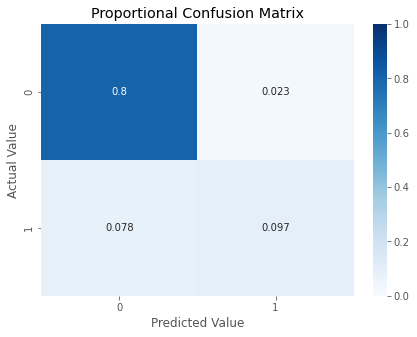

```
Logistic Regression Accuracy: 0.898
Logistic Regression F-Score: 0.657
Logistic Regression AUC: 0.915
```

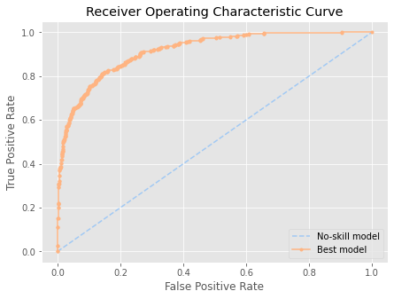

```python
# define the model
lg_model = LogisticRegression(solver='liblinear', random_state=0)

# train the model
lg_result = lg_model.fit(X_train, y_train)

# prediction
lg_predicted = lg_result.predict(X_test)
lg_predicted_proba = lg_result.predict_proba(X_test)
lg_predicted_proba = [i[1] for i in lg_predicted_proba]

# confusion matrix
lg_conf_mat = confusion_matrix(y_true = y_test, y_pred = lg_predicted)
print("Logistic Regression Confusion Matrix:")
print(lg_conf_mat)
print('\n\n')
# display confusion matrix heatmap
confusion_matrix_heatmap(lg_conf_mat)

print('\n\n')

# Evaluation
lg_accuracy = accuracy_score(y_true = y_test, y_pred = lg_predicted)
lg_fscore = f1_score(y_true = y_test, y_pred = lg_predicted)
lg_roc_auc = roc_auc_score(y_true = y_test, y_score = lg_predicted_proba)
print("Logistic Regression Accuracy:", round(lg_accuracy,3))
print("Logistic Regression F-Score:", round(lg_fscore, 3))
print("Logistic Regression AUC:", round(lg_roc_auc, 3))
print('\n\n')
# display ROC curve
auc_visualization(y_test, lg_predicted_proba)
```

##### 5.1.2. Hyperparameter Tuning

##### 1st iteration

```python
# specify parameters
lg_param_grid_1 = {'solver': ['newton-cg', 'lbfgs', 'liblinear', 'sag', 'saga'],
                   'penalty': ['l1', 'l2', 'elasticnet', 'none'],
                   'C': [0.01, 0.1, 1, 10, 100],
                   }

# search algorithm
lg_search_1 = GridSearchCV(lg_model,
                           lg_param_grid_1,
                           scoring = 'roc_auc',
                           cv = 10,
                           n_jobs = -1,
                           verbose = 1)

# train
lg_tune_result_1 = lg_search_1.fit(X_train, y_train)
```

```
Fitting 10 folds for each of 100 candidates, totalling 1000 fits
```

```python
# best hyperparameter
print('Best hyperparameter:', lg_tune_result_1.best_params_)
```

```
Best hyperparameter: {'C': 100, 'penalty': 'l1', 'solver': 'saga'}
```

##### 2nd Iteration

```python
# specify parameters
lg_param_grid_2 = {'solver': ['saga'],
                   'penalty': ['l1'],
                   'C': [30, 40, 60, 80, 100, 120, 130],
                   }

# search algorithm
lg_search_2 = GridSearchCV(lg_model,
                           lg_param_grid_2,
                           scoring = 'roc_auc',
                           cv = 10,
                           n_jobs = -1,
                           verbose = 1)

# train
lg_tune_result_2 = lg_search_2.fit(X_train, y_train)
```

```
Fitting 10 folds for each of 7 candidates, totalling 70 fits
```

```python
# best hyperparameter
print('Best hyperparameter:', lg_tune_result_2.best_params_)
```

```
Best hyperparameter: {'C': 30, 'penalty': 'l1', 'solver': 'saga'}
```

##### 3rd iteration

```python
# specify parameters
lg_param_grid_3 = {'solver': ['saga'],
                   'penalty': ['l1'],
                   'C': [15, 20, 25, 30, 35],
                   }
# search algorithm
lg_search_3 = GridSearchCV(lg_model,
                           lg_param_grid_3,
                           scoring = 'roc_auc',
                           cv = 10,
                           n_jobs = -1,
                           verbose = 1)

# train
lg_tune_result_3 = lg_search_3.fit(X_train, y_train)
```

```
Fitting 10 folds for each of 5 candidates, totalling 50 fits
```

```python
# best hyperparameter
print('Best hyperparameter:', lg_tune_result_3.best_params_)
```

```
Best hyperparameter: {'C': 30, 'penalty': 'l1', 'solver': 'saga'}
```

##### 4th Iteration

```python
# specify parameters
lg_param_grid_4 = {'solver': ['saga'],
                   'penalty': ['l1'],
                   'C': [26,27,28,29,30,31,32,33,34],
                   }
# search algorithm
lg_search_4 = GridSearchCV(lg_model,
                           lg_param_grid_4,
                           scoring = 'roc_auc',
                           cv = 10,
                           n_jobs = -1,
                           verbose = 1)

# train
lg_tune_result_4 = lg_search_4.fit(X_train, y_train)
```

```
Fitting 10 folds for each of 9 candidates, totalling 90 fits
```

```python
# best hyperparameter
print('Best hyperparameter:', lg_tune_result_4.best_params_)
```

```
Best hyperparameter: {'C': 30, 'penalty': 'l1', 'solver': 'saga'}
```

##### Compare Score

```python
print('Best score 1st:', lg_tune_result_1.best_score_)
print('Best score 2nd:', lg_tune_result_2.best_score_)
print('Best score 3rd:', lg_tune_result_3.best_score_)
print('Best score 4th:', lg_tune_result_4.best_score_)
```

```
Best score 1st: 0.9367578250498519
Best score 2nd: 0.9367707912420563
Best score 3rd: 0.9367707912420563
Best score 4th: 0.9367707912420563
```

##### Conclusion

After four iteration, the hyperparameter 'C':30 didn't change since the 2nd iteration. We decided to stop the iteration, and use best hyperparameter as found by the 4th iteration.

### 5.1.3. Model Comparison After Tuning

##### New Model

```
New Logistic Regression Confusion Matrix:
[[1834   70]
 [ 159  247]]
```

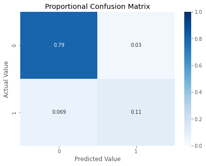

```
New Logistic Regression Accuracy: 0.9009
New Logistic Regression F-Score: 0.6833
New Logistic Regression AUC: 0.9215
```

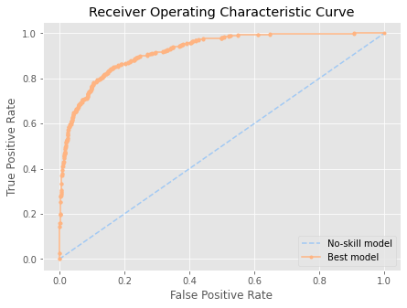

```python
# define the model
new_lg_model = LogisticRegression(random_state=0,
                                  **lg_tune_result_4.best_params_)

# train the model
new_lg_result = new_lg_model.fit(X_train, y_train)

# prediction
new_lg_predicted = new_lg_result.predict(X_test)
new_lg_predicted_proba = new_lg_result.predict_proba(X_test)
new_lg_predicted_proba = [i[1] for i in new_lg_predicted_proba]

# confusion matrix
new_lg_conf_mat = confusion_matrix(y_true = y_test, y_pred = new_lg_predicted)
print("New Logistic Regression Confusion Matrix:")
print(new_lg_conf_mat)
print('\n\n')
# display confusion matrix heatmap
confusion_matrix_heatmap(new_lg_conf_mat)

print('\n\n')

# Evaluation
new_lg_accuracy = accuracy_score(y_true = y_test, y_pred = new_lg_predicted)
new_lg_fscore = f1_score(y_true = y_test, y_pred = new_lg_predicted)
new_lg_roc_auc = roc_auc_score(y_true = y_test, y_score = new_lg_predicted_proba)
print("New Logistic Regression Accuracy:", round(new_lg_accuracy,4))
print("New Logistic Regression F-Score:", round(new_lg_fscore, 4))
print("New Logistic Regression AUC:", round(new_lg_roc_auc, 4))
print('\n\n')
# display ROC curve
auc_visualization(y_test, new_lg_predicted_proba)
```

```python
# comparison
print("Logistic Regression Accuracy:", round(lg_accuracy,4))
print("Logistic Regression F-Score:", round(lg_fscore, 4))
print("Logistic Regression AUC:", round(lg_roc_auc, 4))
print('===')
print("New Logistic Regression Accuracy:", round(new_lg_accuracy,4))
print("New Logistic Regression F-Score:", round(new_lg_fscore, 4))
print("New Logistic Regression AUC:", round(new_lg_roc_auc, 4))
```

```
Logistic Regression Accuracy: 0.8983
Logistic Regression F-Score: 0.6569
Logistic Regression AUC: 0.9154
===
New Logistic Regression Accuracy: 0.9009
New Logistic Regression F-Score: 0.6833
New Logistic Regression AUC: 0.9215
```

### 5.2. k-NN

```python
# import required libraries
from sklearn.neighbors import KNeighborsClassifier
```

##### 5.2.1. Modelling and Evaluation

```
k-NN Confusion Matrix:
[[1851   53]
 [ 242  164]]
```

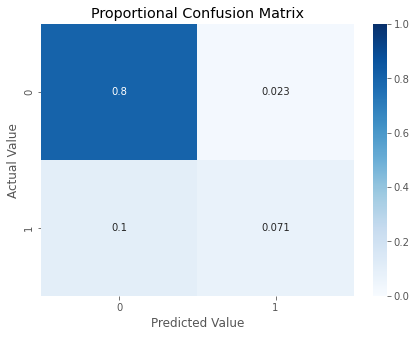

```
k-NN Accuracy: 0.872
k-NN F-Score: 0.526
k-NN AUC: 0.835
```

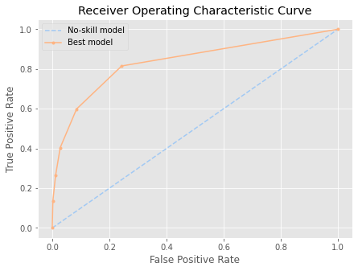

```python
# define the model
knn_model = KNeighborsClassifier()

# train the model
knn_result = knn_model.fit(X_train, y_train)

# prediction
knn_predicted = knn_result.predict(X_test)
knn_predicted_proba = knn_result.predict_proba(X_test)
knn_predicted_proba = [i[1] for i in knn_predicted_proba]

# confusion matrix
knn_conf_mat = confusion_matrix(y_true = y_test, y_pred = knn_predicted)
print("k-NN Confusion Matrix:")
print(knn_conf_mat)
print('\n\n')
# display confusion matrix heatmap
confusion_matrix_heatmap(knn_conf_mat)

print('\n\n')

# Evaluation
knn_accuracy = accuracy_score(y_true = y_test, y_pred = knn_predicted)
knn_fscore = f1_score(y_true = y_test, y_pred = knn_predicted)
knn_roc_auc = roc_auc_score(y_true = y_test, y_score = knn_predicted_proba)
print("k-NN Accuracy:", round(knn_accuracy,3))
print("k-NN F-Score:", round(knn_fscore, 3))
print("k-NN AUC:", round(knn_roc_auc, 3))
print('\n\n')
# display ROC curve
auc_visualization(y_test, knn_predicted_proba)
```

##### 5.2.2. Hyperparameter Tuning

1st Iteration

```python
# specify parameters
knn_param_grid_1 = {'n_neighbors': list(range(1,22,2)),
                    'metric': ['euclidean', 'manhattan', 'minkowski'],
                    'weights': ['uniform', 'distance'],
                    'algorithm': ['auto', 'ball_tree', 'kd_tree', 'brute'],
                    }

# search algorithm
knn_search_1 = GridSearchCV(knn_model,
                           knn_param_grid_1,
                           scoring = 'roc_auc',
                           cv = 10,
                           n_jobs = -1,
                           verbose = 1)

# train
knn_tune_result_1 = knn_search_1.fit(X_train, y_train)
```

```
Fitting 10 folds for each of 264 candidates, totalling 2640 fits
```

```python
# best hyperparameter
print('Best hyperparameter:', knn_tune_result_1.best_params_)
```

```
Best hyperparameter: {'algorithm': 'auto', 'metric': 'manhattan', 'n_neighbors': 21, 'weights': 'distance'}
```

##### 2nd Iteration

```python
# specify parameters
knn_param_grid_2 = {'n_neighbors': list(range(21,50,2)),
                    'metric': ['manhattan'],
                    'weights': ['distance'],
                    'algorithm': ['auto'],
                    }

# search algorithm
knn_search_2 = GridSearchCV(knn_model,
                           knn_param_grid_2,
                           scoring = 'roc_auc',
                           cv = 10,
                           n_jobs = -1,
                           verbose = 1)

# train
knn_tune_result_2 = knn_search_2.fit(X_train, y_train)
```

```
Fitting 10 folds for each of 15 candidates, totalling 150 fits
```

```python
# best hyperparameter
print('Best hyperparameter:', knn_tune_result_2.best_params_)
```

```
Best hyperparameter: {'algorithm': 'auto', 'metric': 'manhattan', 'n_neighbors': 45, 'weights': 'distance'}
```

##### 3rd Iteration

```python
# specify parameters
knn_param_grid_3 = {'n_neighbors': [45,47,49,51,52,53],
                    'metric': ['manhattan'],
                    'weights': ['distance'],
                    'algorithm': ['auto'],
                    }

# search algorithm
knn_search_3 = GridSearchCV(knn_model,
                           knn_param_grid_3,
                           scoring = 'roc_auc',
                           cv = 10,
                           verbose = 1)

# train
knn_tune_result_3 = knn_search_3.fit(X_train, y_train)
```

```
Fitting 10 folds for each of 6 candidates, totalling 60 fits
```

```python
# best hyperparameter
print('Best hyperparameter:', knn_tune_result_3.best_params_)
```

```
Best hyperparameter: {'algorithm': 'auto', 'metric': 'manhattan', 'n_neighbors': 45, 'weights': 'distance'}
```

### Compare Score

```python
print('Best score 1st:', knn_tune_result_1.best_score_)
print('Best score 2nd:', knn_tune_result_2.best_score_)
print('Best score 3rd:', knn_tune_result_3.best_score_)
```

```
Best score 1st: 0.9207219172985989
Best score 2nd: 0.92497506482673
Best score 3rd: 0.92497506482673
```

##### Conclusion

use hyperparameters as found by 3rd iteration

### 5.2.3. Model Comparison After Tuning

##### New Model

```
New k-NN Confusion Matrix:
[[1891   13]
 [ 285  121]]
```

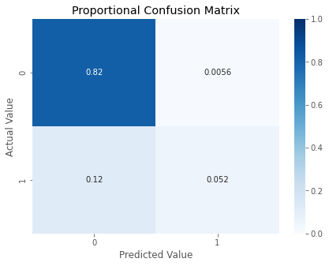

```
New k-NN Accuracy: 0.871
New k-NN F-Score: 0.448
New k-NN AUC: 0.907
```

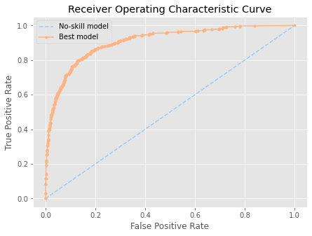

```python
# define the model
new_knn_model = KNeighborsClassifier(**knn_tune_result_3.best_params_)

# train the model
new_knn_result = new_knn_model.fit(X_train, y_train)

# prediction
new_knn_predicted = new_knn_result.predict(X_test)
new_knn_predicted_proba = new_knn_result.predict_proba(X_test)
new_knn_predicted_proba = [i[1] for i in new_knn_predicted_proba]

# confusion matrix
new_knn_conf_mat = confusion_matrix(y_true = y_test, y_pred = new_knn_predicted)
print("New k-NN Confusion Matrix:")
print(new_knn_conf_mat)
print('\n\n')
# display confusion matrix heatmap
confusion_matrix_heatmap(new_knn_conf_mat)

print('\n\n')

# Evaluation
new_knn_accuracy = accuracy_score(y_true = y_test, y_pred = new_knn_predicted)
new_knn_fscore = f1_score(y_true = y_test, y_pred = new_knn_predicted)
new_knn_roc_auc = roc_auc_score(y_true = y_test, y_score = new_knn_predicted_proba)
print("New k-NN Accuracy:", round(new_knn_accuracy,3))
print("New k-NN F-Score:", round(new_knn_fscore, 3))
print("New k-NN AUC:", round(new_knn_roc_auc, 3))
print('\n\n')
# display ROC curve
auc_visualization(y_test, new_knn_predicted_proba)
```

##### Score Comparison

```python
# comparison
print("k-NN Accuracy:", round(knn_accuracy,4))
print("k-NN F-Score:", round(knn_fscore, 4))
print("k-NN AUC:", round(knn_roc_auc, 4))
print('===')
print("New k-NN Accuracy:", round(new_knn_accuracy,4))
print("New k-NN F-Score:", round(new_knn_fscore, 4))
print("New k-NN AUC:", round(new_knn_roc_auc, 4))
```

```
k-NN Accuracy: 0.8723
k-NN F-Score: 0.5265
k-NN AUC: 0.8348
===
New k-NN Accuracy: 0.871
New k-NN F-Score: 0.4481
New k-NN AUC: 0.9073
```

The tuned model AUC score is higher than the default model's, but the F-Score is not. It is because the 'scoring' parameter on GridSearchCV is set to 'roc_auc' as we want to predict the probability of the churn.

### 5.3. Random Forest

```python
# import required libraries
from sklearn.ensemble import RandomForestClassifier
```

##### 5.3.1. Modelling and Evaluation

```
Random Forest Confusion Matrix:
[[1866   38]
 [  59  347]]
```

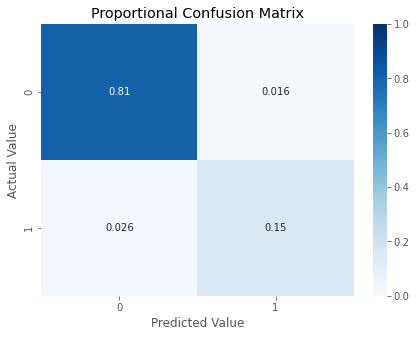

```
Random Forest Accuracy: 0.958
Random Forest F-Score: 0.877
Random Forest AUC: 0.983
```

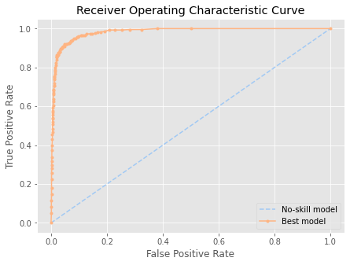

```python
# define the model
rf_model = RandomForestClassifier(random_state=0)

# train the model
rf_result = rf_model.fit(X_train, y_train)

# prediction
rf_predicted = rf_result.predict(X_test)
rf_predicted_proba = rf_result.predict_proba(X_test)
rf_predicted_proba = [i[1] for i in rf_predicted_proba]

# confusion matrix
rf_conf_mat = confusion_matrix(y_true = y_test, y_pred = rf_predicted)
print("Random Forest Confusion Matrix:")
print(rf_conf_mat)
print('\n\n')
# display confusion matrix heatmap
confusion_matrix_heatmap(rf_conf_mat)

print('\n\n')

# Evaluation
rf_accuracy = accuracy_score(y_true = y_test, y_pred = rf_predicted)
rf_fscore = f1_score(y_true = y_test, y_pred = rf_predicted)
rf_roc_auc = roc_auc_score(y_true = y_test, y_score = rf_predicted_proba)
print("Random Forest Accuracy:", round(rf_accuracy,3))
print("Random Forest F-Score:", round(rf_fscore, 3))
print("Random Forest AUC:", round(rf_roc_auc, 3))
print('\n\n')
# display ROC curve
auc_visualization(y_test, rf_predicted_proba)
```

##### 5.3.2. Hyperparameter Tuning

1st Iteration

```python
# specify parameters
rf_param_grid_1 = {'n_estimators': [10,100,1000],
                   'max_depth': [5, 10, 15],
                   'min_samples_split': [2,3,4,5],
                   'min_samples_leaf': [1,2,3],
                   'max_features': ['auto','sqrt','log2']
                   }

# search algorithm
rf_search_1 = GridSearchCV(rf_model,
                           rf_param_grid_1,
                           scoring = 'roc_auc',
                           cv = 5,
                           n_jobs=-1,
                           verbose = 1)

# train
rf_tune_result_1 = rf_search_1.fit(X_train, y_train)
```

```
Fitting 5 folds for each of 324 candidates, totalling 1620 fits
```

```python
# best hyperparameter
print('Best hyperparameter:', rf_tune_result_1.best_params_)
```

[output not shown]

2nd Iteration

```python
# specify parameters
rf_param_grid_2 = {'n_estimators': [900, 1000, 1100, 1200],
                   'max_depth': [14, 15, 16],
                   'min_samples_split': [2],
                   'min_samples_leaf': [1],
                   'max_features': ['auto']
                   }


# search algorithm
rf_search_2 = GridSearchCV(rf_model,
                           rf_param_grid_2,
                           scoring = 'roc_auc',
                           cv = 5,
                           n_jobs=-1,
                           verbose = 1)

# train
rf_tune_result_2 = rf_search_2.fit(X_train, y_train)
```

```python
# best hyperparameter
print('Best hyperparameter:', rf_tune_result_2.best_params_)
```

[output not shown]

3rd Iteration

```python
# specify parameters
rf_param_grid_3 = {'n_estimators': [700, 800, 900],
                   'max_depth': [15],
                   'min_samples_split': [2],
                   'min_samples_leaf': [1],
                   'max_features': ['auto']
                   }

# search algorithm
rf_search_3 = GridSearchCV(rf_model,
                           rf_param_grid_3,
                           scoring = 'roc_auc',
                           cv = 5,
                           n_jobs=-1,
                           verbose = 1)

# train
rf_tune_result_3 = rf_search_3.fit(X_train, y_train)
```

```python
# best hyperparameter
print('Best hyperparameter:', rf_tune_result_3.best_params_)
```

[output not shown]

4th Iteration

```python
# specify parameters
rf_param_grid_4 = {'n_estimators': [840, 860, 880, 900],
                   'max_depth': [15],
                   'min_samples_split': [2],
                   'min_samples_leaf': [1],
                   'max_features': ['auto'],
                   'criterion': ['gini','entropy']  #new hyperparameter addition
                   }

# search algorithm
rf_search_4 = GridSearchCV(rf_model,
                           rf_param_grid_4,
                           scoring = 'roc_auc',
                           cv = 5,
                           n_jobs=-1,
                           verbose = 1)

# train
rf_tune_result_4 = rf_search_4.fit(X_train, y_train)
```

```python
# best hyperparameter
print('Best hyperparameter:', rf_tune_result_4.best_params_)
```

[output not shown]

5th Iteration

```python
# specify parameters
rf_param_grid_5 = {'n_estimators': [890, 895,900, 905],
                   'max_depth': [15],
                   'min_samples_split': [2],
                   'min_samples_leaf': [1],
                   'max_features': ['auto'],
                   'criterion': ['entropy']
                   }

# search algorithm
rf_search_5 = GridSearchCV(rf_model,
                           rf_param_grid_5,
                           scoring = 'roc_auc',
                           cv = 10,
                           n_jobs=-1,
                           verbose = 1)

# train
rf_tune_result_5 = rf_search_5.fit(X_train, y_train)
```

```python
# best hyperparameter
print('Best hyperparameter:', rf_tune_result_5.best_params_)
```

[output not shown]

### Compare Score

```python
print('Best score 1st:', rf_tune_result_1.best_score_)
print('Best score 2nd:', rf_tune_result_2.best_score_)
print('Best score 3rd:', rf_tune_result_3.best_score_)
print('Best score 4th:', rf_tune_result_4.best_score_)
print('Best score 5th:', rf_tune_result_5.best_score_)
```

[output not shown]

### 5.3.3. Model Comparison After Tuning

```python
# define the model
rf_model = RandomForestClassifier(random_state=0)

# train the model
rf_result = rf_model.fit(X_train, y_train)

# prediction
rf_predicted = rf_result.predict(X_test)
rf_predicted_proba = rf_result.predict_proba(X_test)
rf_predicted_proba = [i[1] for i in rf_predicted_proba]

# confusion matrix
rf_conf_mat = confusion_matrix(y_true = y_test, y_pred = rf_predicted)
print("Random Forest Confusion Matrix:")
print(rf_conf_mat)
print('\n\n')
# display confusion matrix heatmap
confusion_matrix_heatmap(rf_conf_mat)

print('\n\n')

# Evaluation
rf_accuracy = accuracy_score(y_true = y_test, y_pred = rf_predicted)
rf_fscore = f1_score(y_true = y_test, y_pred = rf_predicted)
rf_roc_auc = roc_auc_score(y_true = y_test, y_score = rf_predicted_proba)
print("Random Forest Accuracy:", round(rf_accuracy,3))
print("Random Forest F-Score:", round(rf_fscore, 3))
print("Random Forest AUC:", round(rf_roc_auc, 3))
print('\n\n')
# display ROC curve
auc_visualization(y_test, rf_predicted_proba)
```

[output not shown]

```python
# comparison
print("Random Forest Accuracy:", round(rf_accuracy,4))
print("Random Forest F-Score:", round(rf_fscore, 4))
print("Random Forest AUC:", round(rf_roc_auc, 4))
print('===')
print("New Random Forest Accuracy:", round(new_rf_accuracy,4))
print("New Random Forest F-Score:", round(new_rf_fscore, 4))
print("New Random Forest AUC:", round(new_rf_roc_auc, 4))
```

[output not shown]

### 5.4. Conclusion

##### Best Model

```python
print("New Logistic Regression AUC:", round(new_lg_roc_auc, 4))
print("New k-NN AUC:", round(new_knn_roc_auc, 4))
print("New Random Forest AUC:", round(new_rf_roc_auc, 4))
```

[output not shown]

##### Feature Importance

```python
new_rf_model.feature_importances_
```

[output not shown]

```python
len(X.columns)
```

```python
# feature importance dataframe
feat_imp = pd.DataFrame({'Feature': X.columns,
                         'Importance': new_rf_model.feature_importances_})
feat_imp_sort = feat_imp.sort_values(by='Importance', ascending=False)
feat_imp_sort
```

[output not shown]

```python
# display as figure
plt.figure(figsize=(7,5))
sns.barplot(x=feat_imp_sort['Importance'], y=feat_imp_sort['Feature'], color='#a2c9f4')
plt.ylabel('')
plt.xlabel('Importance')
plt.title('Feature Importance', fontsize=12)
plt.show()
```

[output not shown]